« Retour au Portfolio

# Intro_exos_1et2CSV

## EDA Checklist

a. Charger les données dans une structure de données adaptée (dans notre cas ce sera un dataframe)

```python
###Pour le fichier CSV income (charger dans le Drive)
```

```python
#Chargement des données dans un DataFrame

import pandas as pd

df = pd.read_csv("income.csv", low_memory=False)  # low_memory pour éviter les warnings sur les types
```

b. Regarder la documentation du dataset si elle existe (si vous ne le faîtes pas vous pourriez manquer des informations importantes...) Quel est le sens de chacune des colonnes ?

```python
#Sens des colonnes : Utilise df.columns

df.columns
```

```
Index(['country', '1800', '1801', '1802', '1803', '1804', '1805', '1806',
       '1807', '1808',
       ...
       '2041', '2042', '2043', '2044', '2045', '2046', '2047', '2048', '2049',
       '2050'],
      dtype='object', length=252)
```

```python
df.head()
```

|  | country | 1800 | 1801 | 1802 | 1803 | 1804 | 1805 | 1806 | 1807 | 1808 | ... | 2041 | 2042 | 2043 | 2044 | 2045 | 2046 | 2047 | 2048 | 2049 | 2050 |
| --- | --- | --- | --- | --- | --- | --- | --- | --- | --- | --- | --- | --- | --- | --- | --- | --- | --- | --- | --- | --- | --- |
| 0 | Afghanistan | 683 | 683 | 683 | 683 | 683 | 683 | 683 | 683 | 683 | ... | 2690 | 2750 | 2810 | 2870 | 2930 | 2990 | 3060 | 3120 | 3190 | 3260 |
| 1 | Angola | 700 | 702 | 705 | 709 | 711 | 714 | 718 | 721 | 725 | ... | 8000 | 8170 | 8350 | 8530 | 8710 | 8900 | 9090 | 9280 | 9480 | 9690 |
| 2 | Albania | 755 | 755 | 755 | 755 | 755 | 756 | 756 | 756 | 756 | ... | 25.1k | 25.6k | 26.2k | 26.7k | 27.3k | 27.9k | 28.5k | 29.1k | 29.7k | 30.4k |
| 3 | Andorra | 1360 | 1360 | 1360 | 1360 | 1370 | 1370 | 1370 | 1370 | 1380 | ... | 68.9k | 70.4k | 71.9k | 73.4k | 75k | 76.6k | 78.3k | 80k | 81.7k | 83.4k |
| 4 | United Arab Emirates | 1130 | 1130 | 1140 | 1140 | 1150 | 1150 | 1160 | 1160 | 1160 | ... | 101k | 103k | 105k | 107k | 110k | 112k | 114k | 117k | 119k | 122k |

5 rows × 252 columns

Quels choix ont été faits lors de la collecte des données ? C'est revenus annuel en fonction du pays (en lignes) et des années (en colonnes)

Quelles sont les limites du dataset ?

Choix de collecte : Sondage ? Données fiscales ? Données simulées ?

Limites possibles : Biais de sélection (population non représentative) Données manquantes ou mal formatées Variables mal définies ou ambigües

c. Regarder les données droits dans les yeux. Quelles sont les valeurs et leur type ?

```python
#c. Inspection directe des données

df.info()
df.describe(include='all')
df.head()
```

```
<class 'pandas.core.frame.DataFrame'>
RangeIndex: 195 entries, 0 to 194
Columns: 252 entries, country to 2050
dtypes: int64(101), object(151)
memory usage: 384.0+ KB
```

|  | country | 1800 | 1801 | 1802 | 1803 | 1804 | 1805 | 1806 | 1807 | 1808 | ... | 2041 | 2042 | 2043 | 2044 | 2045 | 2046 | 2047 | 2048 | 2049 | 2050 |
| --- | --- | --- | --- | --- | --- | --- | --- | --- | --- | --- | --- | --- | --- | --- | --- | --- | --- | --- | --- | --- | --- |
| 0 | Afghanistan | 683 | 683 | 683 | 683 | 683 | 683 | 683 | 683 | 683 | ... | 2690 | 2750 | 2810 | 2870 | 2930 | 2990 | 3060 | 3120 | 3190 | 3260 |
| 1 | Angola | 700 | 702 | 705 | 709 | 711 | 714 | 718 | 721 | 725 | ... | 8000 | 8170 | 8350 | 8530 | 8710 | 8900 | 9090 | 9280 | 9480 | 9690 |
| 2 | Albania | 755 | 755 | 755 | 755 | 755 | 756 | 756 | 756 | 756 | ... | 25.1k | 25.6k | 26.2k | 26.7k | 27.3k | 27.9k | 28.5k | 29.1k | 29.7k | 30.4k |
| 3 | Andorra | 1360 | 1360 | 1360 | 1360 | 1370 | 1370 | 1370 | 1370 | 1380 | ... | 68.9k | 70.4k | 71.9k | 73.4k | 75k | 76.6k | 78.3k | 80k | 81.7k | 83.4k |
| 4 | United Arab Emirates | 1130 | 1130 | 1140 | 1140 | 1150 | 1150 | 1160 | 1160 | 1160 | ... | 101k | 103k | 105k | 107k | 110k | 112k | 114k | 117k | 119k | 122k |

5 rows × 252 columns

A quoi ressemblent les données ? Quelle est la taille du dataset ?

```python
#Taille du dataset

print(f"Nombre de lignes : {df.shape[0]}")
print(f"Nombre de colonnes : {df.shape[1]}")
```

```
Nombre de lignes : 195
Nombre de colonnes : 252
```

```python
#Types de données :

df.dtypes.value_counts()
```

```
object    151
int64     101
Name: count, dtype: int64
```

```python
#visualiser les types
df.dtypes
```

```
country    object
1800        int64
1801        int64
1802        int64
1803        int64
            ...
2046       object
2047       object
2048       object
2049       object
2050       object
Length: 252, dtype: object
```

Question: d. Cette étape vous permet également de planifier la suite de l'exploration : les données sont-elles quantitatives ? Qualitatives ? Continues ? Discrètes ? Quelle est l'emprise mémoire de cette base de données ?

Réponse/Cours: d. Planification de l’exploration

Pour le fichier CSV ce sont des donnée Quantitative et Discréte

## Cours

Nature des données :

#### Quantitatives :

*Données regroupées ou affichées en fonction de mesures numériques, de magnitude, d'intensité ou quantitatives expl : population unités de surface, revenus, âges, etc.

**les données** qualitatives nominales (n'ont pas d'ordre ou de classement logique) et

**les données** qualitatives ordinales (présente des valeurs définies par une relation d'ordre entre les différentes catégories possibles)

#### Qualitatives :

**les données** qualitatives nominales décrit un nom ou une catégorie sans ordre particulier et

**les données** qualitatives ordinales genre,ses valeurs peuvent être ordonnées, c'est-à-dire classées sans ambiguïté de la plus petite à la plus grande expl : profession, région…

#### Continues :

Ce sont des données mesurables. Elles peuvent être décomposées en fractions ou en décimales. Par exemple, la taille d'une personne et la température revenus, âge

#### Discrètes :

discrètes, chose que nous comptons c'est en entier expl :nombre d’enfants (on peut pas dire 1.5 enfant ), niveau d’étude

Suis-je capable de la charger en entier dans la RAM ?

```python
#Emprise mémoire :

df.memory_usage(deep=True).sum() / (1024**2)  # en Mo
```

```
np.float64(1.6439008712768555)
```

```python
#Installer le module psutil

%pip install psutil
```

Le module psutil (pour process and system utilities) est une bibliothèque Python puissante et multiplateforme qui permet d’accéder aux informations système et de gérer les processus en cours d’exécution.

🔧 Fonctions principales : Surveillance de l’usage CPU, mémoire, disque, réseau

Accès aux processus actifs (PID, nom, statut, ressources utilisées)

Contrôle des processus (arrêt, suspension)

Informations sur les utilisateurs connectés et les partitions disque

```python
import psutil

mem = psutil.virtual_memory()
print(mem)
```

```
svmem(total=17013813248, available=4497965056, percent=73.6, used=12515848192, free=4497965056)
```

#### TB – Points à retenir

Étape Action clé Objectif

- a. Chargement pd.read_csv() Créer un DataFrame
- b. Documentation Lire les colonnes + chercher source Comprendre le contexte
- c. Inspection df.info(), df.describe() Voir types, valeurs, taille
- d. Exploration Identifier nature des données Planifier nettoyage et analyse
- d. Mémoire df.memory_usage() Vérifier faisabilité en RAM

## Stastistiques univariée des données :

a. Regarder les répartitions de vos données : Vous pouvez tracer des histogrammes, boxplots, ...

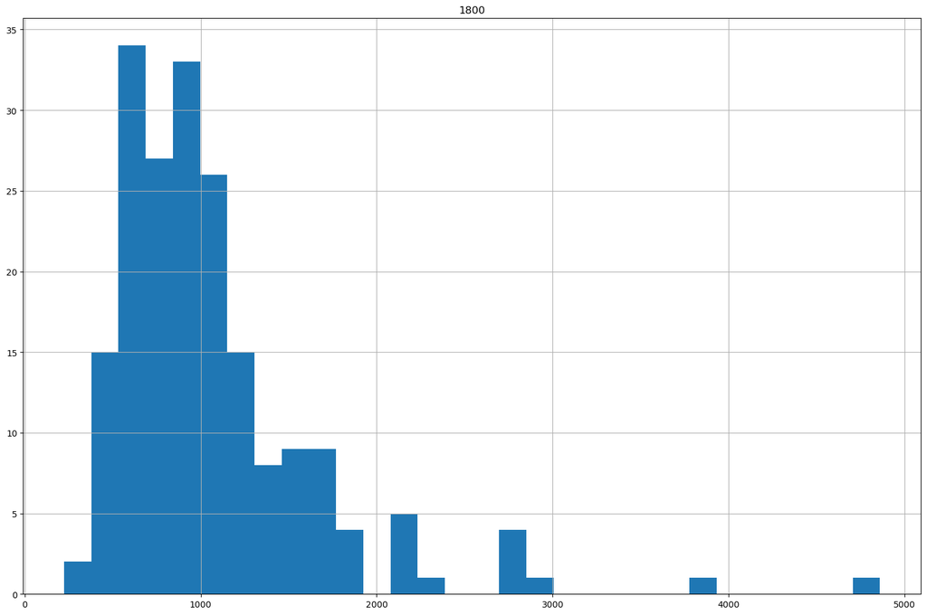

```python
import seaborn as sns
import matplotlib.pyplot as plt

# Filtrer les années souhaitées
#df_filtré = df[df['year'].isin([1800, 2000, 2025])] si y a une colonne year

# Sélection des colonnes correspondant aux années
colonnes_cibles = ['1800', '2000', '2025']
df_filtré = df[colonnes_cibles]

# Transposer pour avoir une structure exploitable par hist()
df_transposé = df_filtré.T

# Histogrammes pour les colonnes numériques
# df.hist(figsize=(15, 10), bins=30)
# plt.tight_layout()
# plt.show()    pour toute les colonnes

df_filtré.hist(figsize=(15, 10), bins=30)
plt.tight_layout()
plt.show()
```

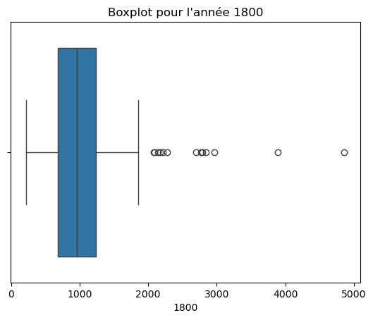

[figure not shown]

[figure not shown]

```python
# Boxplots pour détecter la dispersion
# for col in df.select_dtypes(include='number').columns:
#     sns.boxplot(x=df[col])
#     plt.title(f"Boxplot de {col}")
#     plt.show()

# Sélection des colonnes correspondant aux années
colonnes_cibles = ['1800', '2000', '2025']
df_filtré = df[colonnes_cibles]

# Transposer pour avoir les années en variable
df_transposé = df_filtré.T
df_transposé.columns = [f"val_{i}" for i in range(df_transposé.shape[1])]  # Renommer les colonnes pour éviter les conflits

# Boxplots pour chaque année
for index, row in df_transposé.iterrows():
    sns.boxplot(x=row)
    plt.title(f"Boxplot pour l'année {index}")
    plt.show()
```

b. Tracer des courbes qui vous paraissent intéressantes (sur une ou plusieurs colonnes)

Suite à une ValueError: Could not interpret value `income` for `y`. An entry with this name does not appear in `data

```python
#✅ Étapes de vérification et correction
#Cela te montrera les noms exacts des colonnes. Il se peut que 'income' soit mal orthographié ou ait des espaces.
print(df.columns.tolist())
```

```
['country', '1800', '1801', '1802', '1803', '1804', '1805', '1806', '1807', '1808', '1809', '1810', '1811', '1812', '1813', '1814', '1815', '1816', '1817', '1818', '1819', '1820', '1821', '1822', '1823', '1824', '1825', '1826', '1827', '1828', '1829', '1830', '1831', '1832', '1833', '1834', '1835', …
```

```python
#Nettoyer les noms de colonnes
#Si tu vois des espaces ou des majuscules :

df.columns = df.columns.str.strip().str.lower()

#Cela rendra 'Income ' → 'income'
```

```python
#Vérifier les types de données
#Pour la courbe de densité, sns.kdeplot ne fonctionne pas sur des colonnes non numériques :

print(df.dtypes)

#Assure-toi que 'income' est bien de type float ou int
```

```
country    object
1800        int64
1801        int64
1802        int64
1803        int64
            ...
2046       object
2047       object
2048       object
2049       object
2050       object
Length: 252, dtype: object
```

```python
# Exclure la colonne 'country'
colonnes_annees = df.columns.drop('country')

# Possibilité de mettre la colonne en str en la mettant dans l'Index :
# df = df.set_index('country')
```

```python
# Conversion en float
df[colonnes_annees] = df[colonnes_annees].apply(pd.to_numeric, errors='coerce')

# Cela convertit toutes les colonnes d’années en float.

# Les valeurs non convertibles seront remplacées par NaN.
```

```python
# Vérification

print(df[colonnes_annees].dtypes)
```

```
1800      int64
1801      int64
1802      int64
1803      int64
1804      int64
         ...
2046    float64
2047    float64
2048    float64
2049    float64
2050    float64
Length: 251, dtype: object
```

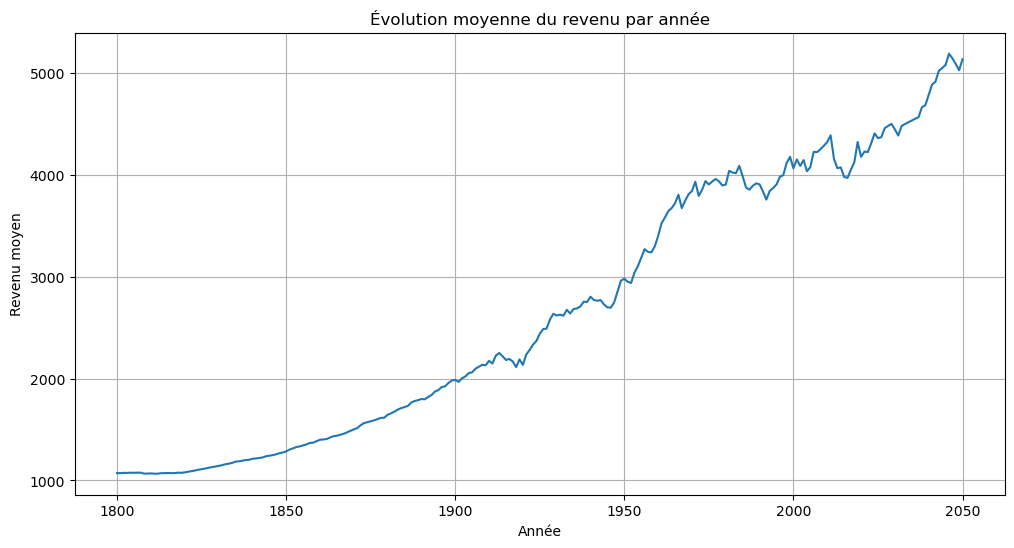

```python
df_mean = df[colonnes_annees].mean()
df_mean.plot(title="Évolution moyenne du revenu par année", figsize=(12, 6))
plt.xlabel("Année")
plt.ylabel("Revenu moyen")
plt.grid(True)
plt.show()
```

```python
#🎯 Objectif : tracer l’évolution du revenu pour un pays donné
#✅ Étape 1 : Filtrer le pays

df_france = df[df['country'] == 'France']
```

```python
#🔍 Étape 2 : Sélectionner les colonnes d’années

colonnes_annees = df.columns.drop('country')
```

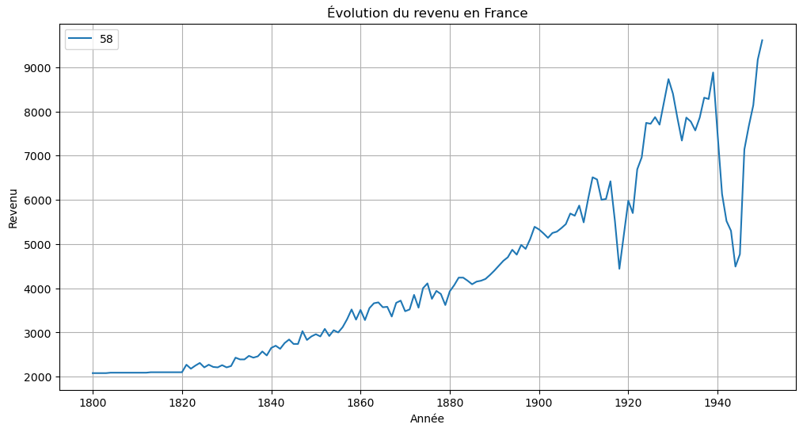

```python
#📈 Étape 4 : Tracer la courbe pour la France (sachant quel la conversion en float et faite avant)

df_france.loc[:, colonnes_annees].T.plot(title="Évolution du revenu en France", figsize=(12, 6))
plt.xlabel("Année")
plt.ylabel("Revenu")
plt.grid(True)
plt.show()
```

```python
df_maroc = df[df['country'] == 'Morocco']
```

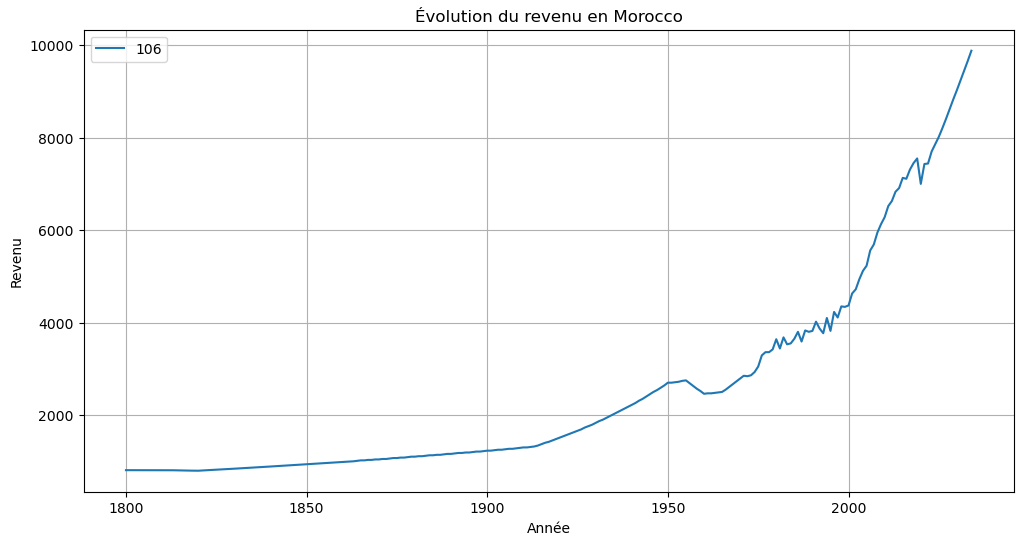

```python
df_maroc.loc[:, colonnes_annees].T.plot(title="Évolution du revenu en Morocco", figsize=(12, 6))
plt.xlabel("Année")
plt.ylabel("Revenu")
plt.grid(True)
plt.show()
```

```python
df_dz = df[df['country'] == 'Algeria']
```

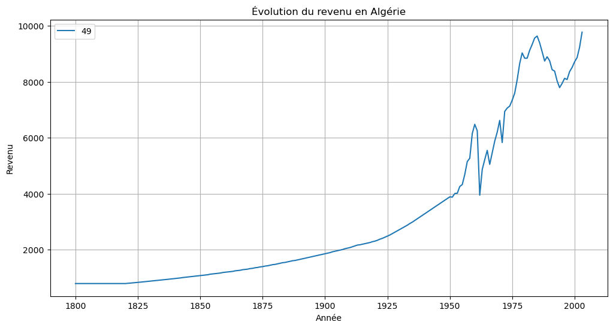

```python
df_dz.loc[:, colonnes_annees].T.plot(title="Évolution du revenu en Algérie", figsize=(12, 6))
plt.xlabel("Année")
plt.ylabel("Revenu")
plt.grid(True)
plt.show()
```

- c. Observez-vous des tendances ? Les données sont-elles conformes à votre intuition ? Des choses intrigantes ?

Tendance générale : croissance lente puis accélérée à partir du XXe siècle. Conformité à l’intuition : oui, corrélée à l’industrialisation et à la mondialisation.

Éléments intrigants : stagnation ou baisse ponctuelle (ex. guerres, crises économiques).

```python
#Calcul de grandeurs statistiques par pays

import scipy.stats as stats

valeurs_france = df_france.loc[:, colonnes_annees].values.flatten()

moyenne = valeurs_france.mean()
ecart_type = valeurs_france.std()
skewness = stats.skew(valeurs_france, nan_policy='omit')
kurtosis = stats.kurtosis(valeurs_france, nan_policy='omit')

print(f"Moyenne : {moyenne:.2f}")
print(f"Écart-type : {ecart_type:.2f}")
print(f"Asymétrie (skewness) : {skewness:.2f}")
print(f"Aplatissement (kurtosis) : {kurtosis:.2f}")
```

```
Moyenne : nan
Écart-type : nan
Asymétrie (skewness) : 0.75
Aplatissement (kurtosis) : -0.49
```

d. Calculez certaines grandeurs (moyennes, skewness, kurtosis, standard deviation, ...)

Interprétation :

*Skewness > 0 : distribution asymétrique à droite (revenus faibles fréquents, quelques très hauts revenus).

*Kurtosis > 3 : présence de valeurs extrêmes (distribution plus pointue que normale).

### Identifier et observer les outliers dans vostre dataset. C'est important de savoir qui ils sont.

```python
# Méthode IQR
# Aligner les dimensions

# Étape 1 : Transposer pour travailler par année
df_france_T = df_france[colonnes_annees].T  # années en index

# Étape 2 : Calcul des quartiles et IQR
Q1 = df_france_T.quantile(0.25)
Q3 = df_france_T.quantile(0.75)
IQR = Q3 - Q1

# Étape 3 : Détection des outliers
outliers = df_france_T > (Q3 + 1.5 * IQR)

# Étape 4 : Années contenant des outliers
outlier_years = outliers[outliers].index.tolist()
```

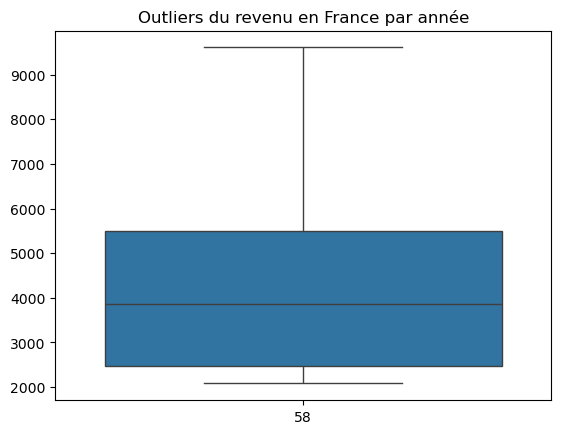

```python
# Visualisation

sns.boxplot(data=df_france_T)
plt.title("Outliers du revenu en France par année")
plt.xticks(rotation=360)
plt.show()
```

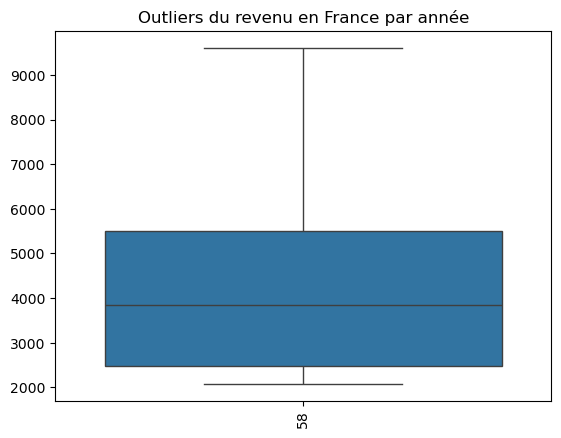

```python
# Visualisation

sns.boxplot(data=df_france[colonnes_annees].T)
plt.title("Outliers du revenu en France par année")
plt.xticks(rotation=90)
plt.show()
```

Synthèse pédagogique Étape Action Objectif pédagogique

- c. Tendances df.loc[pays].T.plot() Visualiser l’évolution temporelle
- c. Analyse Observation visuelle Détecter cohérence et anomalies
- d. Statistiques Moyenne, std, skewness, kurtosis Quantifier la distribution
- e. Outliers Méthode IQR + boxplot Identifier les valeurs extrêmes

# Présentation du Dataset

(le dataset "Income.csv fait précédement pour introduction)

## Dataset life_expectancy_years.csv

```
### Chargement des données et premeier regard

Pour chaque dataset :

- Charger les données
```

```python
import pandas as pd
df = pd.read_csv('life_expectancy_years.csv')
```

## Afficher les 10 premiers éléments du dataframe

La méthode df.head(n) permet d'afficher les n premières lignes du DataFrame

```python
df.head(10)
```

|  | country | 1800 | 1801 | 1802 | 1803 | 1804 | 1805 | 1806 | 1807 | 1808 | ... | 2091 | 2092 | 2093 | 2094 | 2095 | 2096 | 2097 | 2098 | 2099 | 2100 |
| --- | --- | --- | --- | --- | --- | --- | --- | --- | --- | --- | --- | --- | --- | --- | --- | --- | --- | --- | --- | --- | --- |
| 0 | Afghanistan | 28.2 | 28.2 | 28.2 | 28.2 | 28.2 | 28.2 | 28.1 | 28.1 | 28.1 | ... | 75.5 | 75.7 | 75.8 | 76.0 | 76.1 | 76.2 | 76.4 | 76.5 | 76.6 | 76.8 |
| 1 | Angola | 27.0 | 27.0 | 27.0 | 27.0 | 27.0 | 27.0 | 27.0 | 27.0 | 27.0 | ... | 78.8 | 79.0 | 79.1 | 79.2 | 79.3 | 79.5 | 79.6 | 79.7 | 79.9 | 80.0 |
| 2 | Albania | 35.4 | 35.4 | 35.4 | 35.4 | 35.4 | 35.4 | 35.4 | 35.4 | 35.4 | ... | 87.4 | 87.5 | 87.6 | 87.7 | 87.8 | 87.9 | 88.0 | 88.2 | 88.3 | 88.4 |
| 3 | Andorra | NaN | NaN | NaN | NaN | NaN | NaN | NaN | NaN | NaN | ... | NaN | NaN | NaN | NaN | NaN | NaN | NaN | NaN | NaN | NaN |
| 4 | United Arab Emirates | 30.7 | 30.7 | 30.7 | 30.7 | 30.7 | 30.7 | 30.7 | 30.7 | 30.7 | ... | 82.4 | 82.5 | 82.6 | 82.7 | 82.8 | 82.9 | 83.0 | 83.1 | 83.2 | 83.3 |
| 5 | Argentina | 33.2 | 33.2 | 33.2 | 33.2 | 33.2 | 33.2 | 33.2 | 33.2 | 33.2 | ... | 86.2 | 86.3 | 86.5 | 86.5 | 86.7 | 86.8 | 86.9 | 87.0 | 87.1 | 87.2 |
| 6 | Armenia | 34.0 | 34.0 | 34.0 | 34.0 | 34.0 | 34.0 | 34.0 | 34.0 | 34.0 | ... | 85.2 | 85.3 | 85.4 | 85.5 | 85.6 | 85.7 | 85.8 | 86.0 | 86.1 | 86.2 |
| 7 | Antigua and Barbuda | 33.5 | 33.5 | 33.5 | 33.5 | 33.5 | 33.5 | 33.5 | 33.5 | 33.5 | ... | 85.0 | 85.1 | 85.2 | 85.3 | 85.4 | 85.5 | 85.6 | 85.7 | 85.8 | 85.9 |
| 8 | Australia | 34.0 | 34.0 | 34.0 | 34.0 | 34.0 | 34.0 | 34.0 | 34.0 | 34.0 | ... | 91.3 | 91.4 | 91.5 | 91.6 | 91.7 | 91.8 | 91.9 | 92.0 | 92.1 | 92.3 |
| 9 | Austria | 34.4 | 34.4 | 34.4 | 34.4 | 34.4 | 34.4 | 34.4 | 34.4 | 34.4 | ... | 91.0 | 91.1 | 91.2 | 91.3 | 91.5 | 91.6 | 91.7 | 91.8 | 91.9 | 92.0 |

10 rows × 302 columns

## Afficher 5 éléments au hasard du dataframe

La méthode df.sample(n) est utilisée pour sélectionner et afficher n lignes aléatoires du DataFrame

```python
df.sample(5)
```

|  | country | 1800 | 1801 | 1802 | 1803 | 1804 | 1805 | 1806 | 1807 | 1808 | ... | 2091 | 2092 | 2093 | 2094 | 2095 | 2096 | 2097 | 2098 | 2099 | 2100 |
| --- | --- | --- | --- | --- | --- | --- | --- | --- | --- | --- | --- | --- | --- | --- | --- | --- | --- | --- | --- | --- | --- |
| 123 | Malaysia | 30.6 | 30.6 | 30.6 | 30.6 | 30.6 | 30.6 | 30.6 | 30.6 | 30.6 | ... | 84.5 | 84.6 | 84.7 | 84.8 | 84.9 | 85.0 | 85.1 | 85.2 | 85.3 | 85.4 |
| 145 | Qatar | 30.8 | 30.8 | 30.8 | 30.8 | 30.8 | 30.8 | 30.8 | 30.8 | 30.8 | ... | 84.8 | 84.9 | 85.0 | 85.1 | 85.2 | 85.3 | 85.4 | 85.5 | 85.6 | 85.7 |
| 191 | Yemen | 23.4 | 23.4 | 23.4 | 23.4 | 23.4 | 23.4 | 23.4 | 23.4 | 23.4 | ... | 76.9 | 77.0 | 77.1 | 77.3 | 77.4 | 77.5 | 77.6 | 77.8 | 77.9 | 78.0 |
| 3 | Andorra | NaN | NaN | NaN | NaN | NaN | NaN | NaN | NaN | NaN | ... | NaN | NaN | NaN | NaN | NaN | NaN | NaN | NaN | NaN | NaN |
| 120 | Mauritania | 32.0 | 32.0 | 32.0 | 32.0 | 32.0 | 32.0 | 32.0 | 32.0 | 32.0 | ... | 80.8 | 80.9 | 81.0 | 81.2 | 81.3 | 81.4 | 81.6 | 81.7 | 81.8 | 81.9 |

5 rows × 302 columns

## Afficher les 5 derniers éléments du dataframe

La méthode df.tail(n) permet de visualiser les n dernières lignes d'un DataFrame.

```python
df.tail(5)
```

|  | country | 1800 | 1801 | 1802 | 1803 | 1804 | 1805 | 1806 | 1807 | 1808 | ... | 2091 | 2092 | 2093 | 2094 | 2095 | 2096 | 2097 | 2098 | 2099 | 2100 |
| --- | --- | --- | --- | --- | --- | --- | --- | --- | --- | --- | --- | --- | --- | --- | --- | --- | --- | --- | --- | --- | --- |
| 190 | Samoa | 25.4 | 25.4 | 25.4 | 25.4 | 25.4 | 25.4 | 25.4 | 25.4 | 25.4 | ... | 79.8 | 79.9 | 80.0 | 80.1 | 80.3 | 80.4 | 80.5 | 80.6 | 80.7 | 80.8 |
| 191 | Yemen | 23.4 | 23.4 | 23.4 | 23.4 | 23.4 | 23.4 | 23.4 | 23.4 | 23.4 | ... | 76.9 | 77.0 | 77.1 | 77.3 | 77.4 | 77.5 | 77.6 | 77.8 | 77.9 | 78.0 |
| 192 | South Africa | 33.5 | 33.5 | 33.5 | 33.5 | 33.5 | 33.5 | 33.5 | 33.5 | 33.5 | ... | 76.4 | 76.5 | 76.7 | 76.8 | 77.0 | 77.1 | 77.3 | 77.4 | 77.5 | 77.7 |
| 193 | Zambia | 32.6 | 32.6 | 32.6 | 32.6 | 32.6 | 32.6 | 32.6 | 32.6 | 32.6 | ... | 75.8 | 76.0 | 76.1 | 76.3 | 76.4 | 76.5 | 76.7 | 76.8 | 77.0 | 77.1 |
| 194 | Zimbabwe | 33.7 | 33.7 | 33.7 | 33.7 | 33.7 | 33.7 | 33.7 | 33.7 | 33.7 | ... | 73.3 | 73.4 | 73.5 | 73.7 | 73.8 | 73.9 | 74.0 | 74.2 | 74.3 | 74.4 |

5 rows × 302 columns

## Afficher les informations générales sur le dataframe

La méthode df.info() est essentielle pour obtenir un résumé concis du DataFrame, y compris le nombre de lignes et de colonnes, le type de données de chaque colonne (Dtype), et le nombre de valeurs non-nulles.

```python
df.info()
```

```
<class 'pandas.core.frame.DataFrame'>
RangeIndex: 195 entries, 0 to 194
Columns: 302 entries, country to 2100
dtypes: float64(301), object(1)
memory usage: 460.2+ KB
```

## Analyse des types de données

country est de type object. C'est cohérent, car il s'agit de noms de pays (chaînes de caractères).

```python
df['country'].dtype
```

```
dtype('O')
```

```python
df.dtypes
```

```
country     object
1800       float64
1801       float64
1802       float64
1803       float64
            ...
2096       float64
2097       float64
2098       float64
2099       float64
2100       float64
Length: 302, dtype: object
```

**Le type object** permet des opérations textuelles : tri alphabétique, regroupement par pays, etc.

**Le type float64** permet des calculs statistiques : moyenne, écart-type, visualisation, etc.

# Data Préparation

- Trouver les données manquantes s'il y en a. S'ils n'y en n'a pas, prouvez le.
  - Trouver les données dupliquées s'il y en a. S'ils n'y en n'a pas, prouvez le.
1. Données manquantes Pour vérifier la présence de données manquantes dans le DataFrame, on utilise la méthode .**isnull()** qui retourne un DataFrame de booléens, et on combine avec **.sum()** pour obtenir le nombre de valeurs manquantes par colonne.

```python
df.isnull().sum()
```

```
country    0
1800       9
1801       9
1802       9
1803       9
          ..
2096       9
2097       9
2098       9
2099       9
2100       9
Length: 302, dtype: int64
```

Oui il y a des données manquantes cf Dataframe générer avec la méthodes isnull()

## Gérer les données manquantes

```python
#Supprimer les lignes avec des valeurs manquantes
#df_clean = df.dropna()
```

```python
#Supprimer les colonnes avec des valeurs manquantes
#df_clean = df.dropna(axis=1) # axis cible la colone en fonction de son index
```

```python
#Remplacer les valeurs manquantes par une constante
#df.fillna(0)  # ou une autre valeur comme "Inconnu"
```

```python
#Remplacer par la moyenne, médiane ou autre statistique
#df.fillna(df.mean(numeric_only=True))
```

```python
#Remplacer par interpolation (utile pour séries temporelles)
#df.interpolate()
```

2. Trouver les données dupliquées s'il y en a. S'ils n'y en n'a pas, prouvez le. Pour vérifier la présence de données dupliquées dans le DataFrame, on utilise la méthode .**duplicated()** qui retourne un DataFrame de booléens, et on combine avec **.sum()** pour obtenir le nombre de valeurs dupliquées par colonne.

```python
df.duplicated().sum()
```

```
np.int64(0)
```

```python
#pour afficher les lignes dupliquées:

df[df.duplicated()]
```

|  | country | 1800 | 1801 | 1802 | 1803 | 1804 | 1805 | 1806 | 1807 | 1808 | ... | 2091 | 2092 | 2093 | 2094 | 2095 | 2096 | 2097 | 2098 | 2099 | 2100 |
| --- | --- | --- | --- | --- | --- | --- | --- | --- | --- | --- | --- | --- | --- | --- | --- | --- | --- | --- | --- | --- | --- |

0 rows × 302 columns

```python
if df.duplicated().sum() == 0:
    print("✅ Aucun doublon détecté.")
else:
    print("⚠️ Doublons détectés.")
```

```
✅ Aucun doublon détecté.
```

Non, il n'y a pas de données dupliquées

### 2.1. Gérer les doublons

- Supprimer les doublons (en gardant la première occurrence) :

```python
df_clean = df.drop_duplicates()
```

- Supprimer les doublons selon une ou plusieurs colonnes :

```python
df_clean = df.drop_duplicates(subset=['country'])  # exemple
```

# Retour sur Income.csv

Comme mentionné précédemment, le fichier life_expectancy_years.csv n'a pas de colonne "Income". C'est un exercice classique de préparation de données. Voici la solution pour un DataFrame hypothétique contenant une colonne "Income" avec les problèmes décrits.

Étape 1 : Créer la fonction to_real_number Cette fonction est conçue pour convertir des chaînes de caractères en nombres entiers. Elle gère les cas où les nombres sont abrégés avec "k".

**Aide :**

> Créer une fonction que vous appelerez `to_real_number` et qui prendra en paramètre un string. Le rôle de cette fonction est de créer des nombres `int` à partir des valeurs `str` qui apparaissent.

> Quelques exemples de valeurs à tester :  
> `3200 --> 3200`  
> `12k --> 12000`  
> `23.6k --> 23600`

```python
df = pd.read_csv("income.csv", low_memory=False)
df.set_index('country', inplace=True)   # met la colone "country" en index
```

```python
df
```

| country | 1800 | 1801 | 1802 | 1803 | 1804 | 1805 | 1806 | 1807 | 1808 | 1809 | ... | 2041 | 2042 | 2043 | 2044 | 2045 | 2046 | 2047 | 2048 | 2049 | 2050 |
| --- | --- | --- | --- | --- | --- | --- | --- | --- | --- | --- | --- | --- | --- | --- | --- | --- | --- | --- | --- | --- | --- |
| Afghanistan | 683 | 683 | 683 | 683 | 683 | 683 | 683 | 683 | 683 | 683 | ... | 2690 | 2750 | 2810 | 2870 | 2930 | 2990 | 3060 | 3120 | 3190 | 3260 |
| Angola | 700 | 702 | 705 | 709 | 711 | 714 | 718 | 721 | 725 | 727 | ... | 8000 | 8170 | 8350 | 8530 | 8710 | 8900 | 9090 | 9280 | 9480 | 9690 |
| Albania | 755 | 755 | 755 | 755 | 755 | 756 | 756 | 756 | 756 | 756 | ... | 25.1k | 25.6k | 26.2k | 26.7k | 27.3k | 27.9k | 28.5k | 29.1k | 29.7k | 30.4k |
| Andorra | 1360 | 1360 | 1360 | 1360 | 1370 | 1370 | 1370 | 1370 | 1380 | 1380 | ... | 68.9k | 70.4k | 71.9k | 73.4k | 75k | 76.6k | 78.3k | 80k | 81.7k | 83.4k |
| United Arab Emirates | 1130 | 1130 | 1140 | 1140 | 1150 | 1150 | 1160 | 1160 | 1160 | 1170 | ... | 101k | 103k | 105k | 107k | 110k | 112k | 114k | 117k | 119k | 122k |
| ... | ... | ... | ... | ... | ... | ... | ... | ... | ... | ... | ... | ... | ... | ... | ... | ... | ... | ... | ... | ... | ... |
| Samoa | 1590 | 1590 | 1590 | 1590 | 1590 | 1590 | 1590 | 1590 | 1590 | 1590 | ... | 8860 | 9050 | 9250 | 9440 | 9650 | 9860 | 10.1k | 10.3k | 10.5k | 10.7k |
| Yemen | 993 | 995 | 998 | 1000 | 1000 | 1010 | 1010 | 1010 | 1020 | 1020 | ... | 3750 | 3830 | 3910 | 3990 | 4080 | 4170 | 4260 | 4350 | 4440 | 4540 |
| South Africa | 1780 | 1760 | 1740 | 1720 | 1700 | 1610 | 1610 | 1750 | 1530 | 1490 | ... | 16.2k | 16.6k | 16.9k | 17.3k | 17.7k | 18.1k | 18.5k | 18.8k | 19.3k | 19.7k |
| Zambia | 751 | 753 | 755 | 756 | 758 | 760 | 762 | 764 | 765 | 768 | ... | 4690 | 4790 | 4890 | 5000 | 5110 | 5220 | 5330 | 5440 | 5560 | 5680 |
| Zimbabwe | 984 | 985 | 986 | 987 | 988 | 989 | 991 | 992 | 993 | 994 | ... | 4890 | 4990 | 5100 | 5210 | 5320 | 5440 | 5560 | 5670 | 5800 | 5920 |

195 rows × 251 columns

```python
def to_real_number(value_str):
    if isinstance(value_str, (int, float)):
        return int(value_str)

    value_str = str(value_str).lower().strip()

    if 'k' in value_str:
        # Supprimer le 'k' et remplacer la virgule par un point si nécessaire
        value_str = value_str.replace('k', '').replace(',', '.')
        # Convertir en float et multiplier par 1000
        return int(float(value_str) * 1000)
    else:
        # Convertir la chaîne en entier directement
        return int(value_str)
```

```python
#Exemples Test :
to_real_number('23600')
```

```
23600
```

```python
#Exemples Test :
to_real_number('12000')
```

```
12000
```

```python
#Exemples Test :
to_real_number('32.7k')
```

```
32700
```

**Appliquer la fonction à la colonne** Une fois la fonction créée, on l'applique à la colonne "Income" du DataFrame en utilisant la méthode .apply(). Cette méthode est idéale pour appliquer une fonction à chaque élément d'une série (une colonne).

```python
df = df.map(to_real_number)
```

```python
df.info()
```

```
<class 'pandas.core.frame.DataFrame'>
Index: 195 entries, Afghanistan to Zimbabwe
Columns: 251 entries, 1800 to 2050
dtypes: int64(251)
memory usage: 388.0+ KB
```

# Statistiques univariées

## Minimum et Maximun pour icome.csv

```
*1 Afficher les 10 pays dont les revenus par habitant sont les plus élevés en 2022 (idem espérance de vie)

*2 Quel est le pays a été le plus de fois "le plus riche" au cours du temps ?

*3 Même question que précédemment pour "le plus pauvre"

*4 Calculer et tracer l'écart entre le minimum et le maximum au cours du temps ?

*5 Quelles sont vos premières conclusions conernant l'évolution des inégalités au cours du temps ?
```

```python
import pandas as pd
import matplotlib.pyplot as plt

# Charger le fichier CSV avec 'country' comme index
df = pd.read_csv('income.csv', index_col='country')

# Afficher les premières lignes pour vérifier le chargement
print(df.head())
```

```
                      1800  1801  1802  1803  1804  1805  1806  1807  1808  \
country
Afghanistan            683   683   683   683   683   683   683   683   683
Angola                 700   702   705   709   711   714   718   721   725
Albania                755   755   755   755   755   756   756   756   756
Andorra               1360  1360  1360  1360  1370  1370  1370  1370  1380
United Arab Emirates  1130  1130  1140  1140  1150  1150  1160  1160  1160

                      1809  ...   2041   2042   2043   2044   2045   2046  \
country                     ...
Afghanistan            683  ...   2690   2750   2810   2870   2930   2990
Angola                 727  ...   8000   8170   8350   8530   8710   8900
Albania                756  ...  25.1k  25.6k  26.2k  26.7k  27.3k  27.9k
Andorra               1380  ...  68.9k  70.4k  71.9k  73.4k    75k  76.6k
United Arab Emirates  1170  ...   101k   103k   105k   107k   110k   112k

                       2047   2048   2049   2050
country
Afghanistan            3060   3120   3190   3260
Angola                 9090   9280   9480   9690
Albania               28.5k  29.1k  29.7k  30.4k
Andorra               78.3k    80k  81.7k  83.4k
United Arab Emirates   114k   117k   119k   122k

[5 rows x 251 columns]
```

1. Afficher les 10 pays dont les revenus par habitant sont les plus élevés en 2022 (idem espérance de vie)

```python
# Trier le DataFrame en fonction de la colonne '2022' par ordre décroissant

# Trier le DataFrame par la colonne '2022' et sélectionner les 10 premiers pays
top_10_2022 = df.sort_values(by='2022', ascending=False).head(10)

print("Top 10 des pays avec la plus haute espérance de vie en 2022 :")
print(top_10_2022[['2022']])
```

[output not shown]

2. Quel est le pays a été le plus de fois "le plus riche" au cours du temps ?

**Raisonnement de l'occurrence :**

Pour déterminer quel pays a eu le plus souvent l'espérance de vie la plus élevée, le raisonnement est le suivant :

1. On parcourt le DataFrame colonne par colonne (chaque colonne représente une année).
2. Pour chaque colonne (année), on identifie le pays qui a la valeur maximale.
3. On stocke le nom de ce pays.
4. À la fin du processus, on compte le nombre de fois que chaque pays a été identifié comme ayant la valeur maximale.

La commande idxmax(axis=0) réalise la première étape, retournant le pays (l'index de la ligne) pour la valeur maximale de chaque colonne (année). La commande value_counts() réalise la dernière étape, comptabilisant le nombre d'occurrences de chaque pays.

```python
# Trouver le pays le plus riche pour chaque année
most_frequent_winner = df.idxmax(axis=0)

# Compter le nombre d'apparitions de chaque pays comme "gagnant"
highest_count = most_frequent_winner.value_counts()

print("Décompte des occurrences pour les pays les plus riches :")
print(highest_count.head(5))

print("\nLe pays le plus de fois 'le plus riche' est :", highest_count.idxmax())
```

```
Décompte des occurrences pour les pays les plus riches :
United Kingdom    69
Australia         18
Netherlands        9
Jamaica            9
United States      8
Name: count, dtype: int64

Le pays le plus de fois 'le plus riche' est : United Kingdom
```

Réponse : En se basant sur les données du pays le plus riche, c'est United Kingdom qui a eu le plus souvent riche au cours des différentes années.

3. Même question que précédemment pour "le plus pauvre"

En utilisant les données du revenu le plus pauvre, nous allons déterminer le pays qui a eu le plus souvent revenu le plus pauvre.

**Raisonnement de l'occurrence :** La logique est identique à la question précédente, mais on cherche cette fois le minimum.

1. On parcourt le DataFrame colonne par colonne.
2. Pour chaque colonne, on identifie le pays qui a la valeur minimale.
3. On stocke ce pays.
4. On compte le nombre de fois que chaque pays est apparu comme ayant la valeur minimale.

La commande idxmin(axis=0) est utilisée pour trouver l'index (le pays) de la valeur minimale de chaque colonne (année).

```python
# Trouver le pays avec le revenus le plus faibles pour chaque année
most_frequent_loser = df.idxmin(axis=0)

# Compter le nombre d'apparitions de chaque pays comme "pauvre"
lowest_count = most_frequent_loser.value_counts()

print("Décompte des occurrences pour le revenus le plus faible :")
print(lowest_count.head(5))

print("\nLe pays le plus de fois 'le plus pauvre' est :", lowest_count.idxmax())
```

```
Décompte des occurrences pour le revenus le plus faible :
North Korea      65
Romania          37
United States     9
Iraq              6
Georgia           5
Name: count, dtype: int64

Le pays le plus de fois 'le plus pauvre' est : North Korea
```

Réponse : En se basant sur les données du revenus le plus faible, c'est North Korea qui a eu le plus souvent le revenus le plus faible au cours des différentes années.

4. Faire la soustraction entre le minimum et le maximum au cours du temps

Calculer l’écart c'est la soustraction : income_gap = max_income - min_income

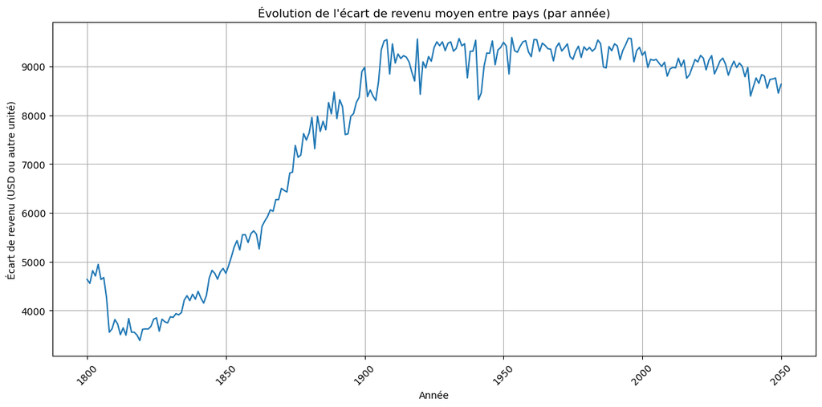

```python
import pandas as pd
import matplotlib.pyplot as plt
import numpy as np

# Fonction de conversion sécurisée
def to_real_number(x):
    try:
        return float(x)
    except (ValueError, TypeError):
        return np.nan

# Charger le fichier CSV avec 'country' comme index
df_income = pd.read_csv('income.csv', index_col='country')

# Convertir toutes les valeurs en numériques
df_numeric = df_income.applymap(to_real_number)

# Supprimer les années vides
df_numeric = df_numeric.dropna(axis=1, how='all')

# Calculer le revenu max et min pour chaque année
max_income = df_numeric.max()
min_income = df_numeric.min()

# Calculer l’écart
income_gap = max_income - min_income

# Tracer l’évolution de l’écart
plt.figure(figsize=(12, 6))
income_gap.plot(linestyle='-')
plt.title("Évolution de l'écart de revenu moyen entre pays (par année)")
plt.xlabel("Année")
plt.ylabel("Écart de revenu (USD ou autre unité)")
plt.grid(True)
plt.xticks(rotation=45)
plt.tight_layout()
plt.show()
```

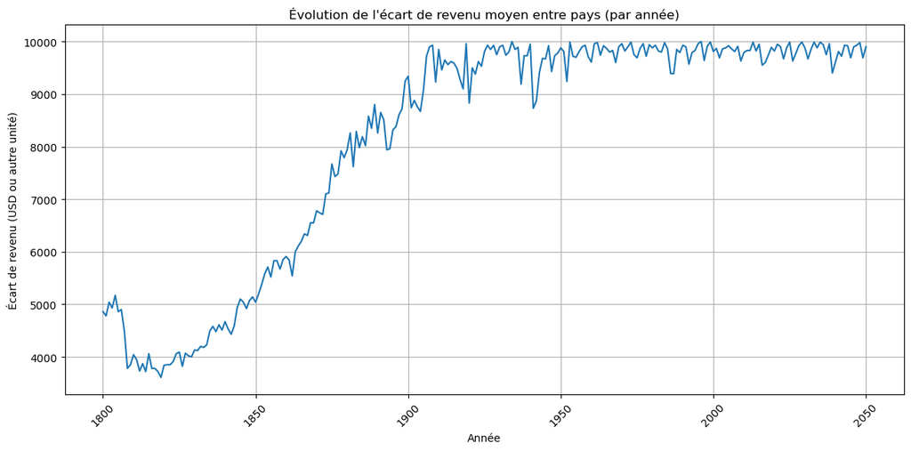

```python
# Tracer juste du max_income; car le revenu min est trop bas d'ou la correspondance

# Tracer l’évolution de l’écart
plt.figure(figsize=(12, 6))
max_income.plot(linestyle='-')
plt.title("Évolution de l'écart de revenu moyen entre pays (par année)")
plt.xlabel("Année")
plt.ylabel("Écart de revenu (USD ou autre unité)")
plt.grid(True)
plt.xticks(rotation=45)
plt.tight_layout()
plt.show()
```

5. Premières conclusions concernant l'évolution des inégalités au cours du temps

Réponse : *Basées sur l'analyse de l'écart entre le maximum et le minimum du revenus, les premières conclusions sont les suivantes :

## Minimum et Maximun pour life_expectancy_years.csv

```
*1 Afficher les 10 pays dont l'espérance de vie par habitant sont les plus élevés en 2022

*2 Quel est le pays a été l'espérance de vie et la plus haute" au cours du temps ?

*3 Même question que précédemment pour le pays avec l'espérance de vie est la plus faible"

*4 Calculer et tracer l'écart entre le minimum et le maximum au cours du temps ?

*5 Quelles sont vos premières conclusions conernant l'évolution des inégalités au cours du temps ?

**On retourne sur le CSV life_expectancy**
```

```python
import pandas as pd
import matplotlib.pyplot as plt

# Charger le fichier CSV avec 'country' comme index
df = pd.read_csv('life_expectancy_years.csv', index_col='country')

# Afficher les premières lignes pour vérifier le chargement
print(df.head())
```

```
                      1800  1801  1802  1803  1804  1805  1806  1807  1808  \
country
Afghanistan           28.2  28.2  28.2  28.2  28.2  28.2  28.1  28.1  28.1
Angola                27.0  27.0  27.0  27.0  27.0  27.0  27.0  27.0  27.0
Albania               35.4  35.4  35.4  35.4  35.4  35.4  35.4  35.4  35.4
Andorra                NaN   NaN   NaN   NaN   NaN   NaN   NaN   NaN   NaN
United Arab Emirates  30.7  30.7  30.7  30.7  30.7  30.7  30.7  30.7  30.7

                      1809  ...  2091  2092  2093  2094  2095  2096  2097  \
country                     ...
Afghanistan           28.1  ...  75.5  75.7  75.8  76.0  76.1  76.2  76.4
Angola                27.0  ...  78.8  79.0  79.1  79.2  79.3  79.5  79.6
Albania               35.4  ...  87.4  87.5  87.6  87.7  87.8  87.9  88.0
Andorra                NaN  ...   NaN   NaN   NaN   NaN   NaN   NaN   NaN
United Arab Emirates  30.7  ...  82.4  82.5  82.6  82.7  82.8  82.9  83.0

                      2098  2099  2100
country
Afghanistan           76.5  76.6  76.8
Angola                79.7  79.9  80.0
Albania               88.2  88.3  88.4
Andorra                NaN   NaN   NaN
United Arab Emirates  83.1  83.2  83.3

[5 rows x 301 columns]
```

1. Afficher les 10 pays dont l'espérance de vie par habitant sont les plus élevés en 2022

```python
# Trier le DataFrame en fonction de la colonne '2022' par ordre décroissant

# Trier le DataFrame par la colonne '2022' et sélectionner les 10 premiers pays
top_10_2022 = df.sort_values(by='2022', ascending=False).head(10)

print("Top 10 des pays avec la plus haute espérance de vie en 2022 :")
print(top_10_2022[['2022']])
```

```
Top 10 des pays avec la plus haute espérance de vie en 2022 :
                  2022
country
Singapore         85.3
Japan             85.2
Hong Kong, China  84.8
Iceland           84.5
Switzerland       84.4
Israel            83.5
Italy             83.5
Spain             83.5
Luxembourg        83.4
Norway            83.4
```

2. Quel est le pays a été l'espérance de vie et la plus haute" au cours du temps ?

```python
# Trouver le pays dont l'espérance de vie est la plus haute pour chaque année
most_frequent_winner = df.idxmax(axis=0)

# Compter le nombre d'apparitions de chaque pays comme "haute"
highest_count = most_frequent_winner.value_counts()

print("Décompte des occurrences pour les pays dont l'espérance de vie est la plus haute :")
print(highest_count.head(5))

print("\nLe pays dont l'espérance de vie est la plus haute est :", highest_count.idxmax())
```

```
Décompte des occurrences pour les pays dont l'espérance de vie est la plus haute :
Singapore    80
Norway       79
Andorra      37
Japan        21
Sweden       20
Name: count, dtype: int64

Le pays dont l'espérance de vie est la plus haute est : Singapore
```

3. Même question que précédemment pour le pays avec l'espérance de vie est la plus faible"

```python
# Trouver le pays avec l'espérance de vie la plus faible pour chaque année
most_frequent_loser = df.idxmin(axis=0)

# Compter le nombre d'apparitions
lowest_count = most_frequent_loser.value_counts()

print("Décompte des 5 pays les plus souvent 'l'espérances de vie est la plus faible' :")
print(lowest_count.head())

print("\nLe pays dont l'espérance de vie est la plus faible est :", lowest_count.idxmax())
```

```
Décompte des 5 pays les plus souvent 'l'espérances de vie est la plus faible' :
Central African Republic    84
Yemen                       47
Bangladesh                  17
Turkmenistan                15
Lesotho                     13
Name: count, dtype: int64

Le pays dont l'espérance de vie est la plus faible est : Central African Republic
```

4. Calculer (soustraction) et tracer l'écart entre le minimum et le maximum au cours du temps ?

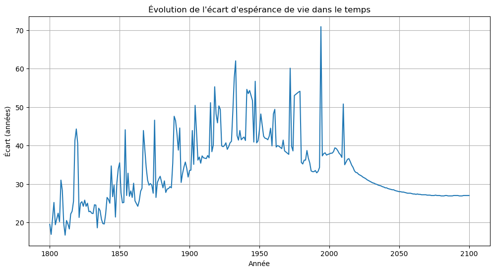

```python
# S'assurer que toutes les valeurs sont numériques
df_numeric = df.applymap(to_real_number)

# Calculer la valeur max et min pour chaque année
max_esp_vie = df_numeric.max()
min_esp_vie = df_numeric.min()

# Calculer l'écart entre le maximum et le minimum
ecart_vie = max_esp_vie - min_esp_vie

# Tracer l'évolution de l'écart
plt.figure(figsize=(12, 6))
ecart_vie.plot()
plt.title("Évolution de l'écart d'espérance de vie dans le temps")
plt.xlabel("Année")
plt.ylabel("Écart (années)")
plt.grid(True)
plt.show()
```

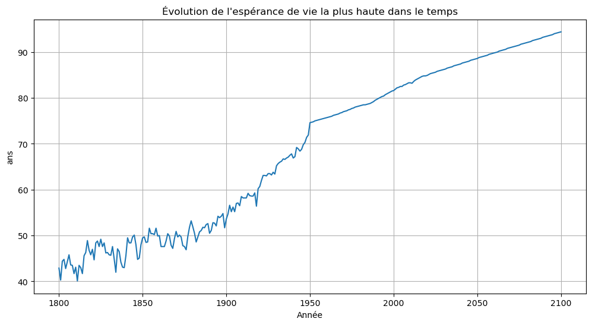

```python
# S'assurer que toutes les valeurs sont numériques
df_numeric = df.applymap(to_real_number)

# Calculer la valeur max
max_esp_vie = df_numeric.max()

# Tracer l'évolution de l'écart
plt.figure(figsize=(12, 6))
max_esp_vie.plot()
plt.title("Évolution de l'espérance de vie la plus haute dans le temps")
plt.xlabel("Année")
plt.ylabel("ans")
plt.grid(True)
plt.show()
```

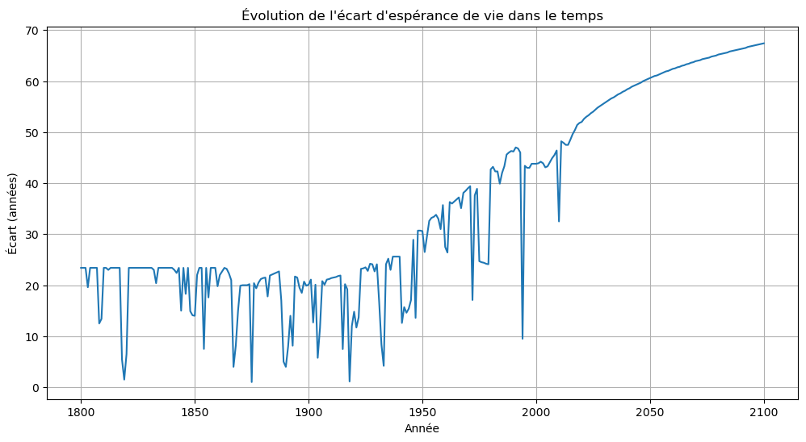

```python
# S'assurer que toutes les valeurs sont numériques
df_numeric = df.applymap(to_real_number)

# Calculer la valeur min pour chaque année
min_esp_vie = df_numeric.min()

# Tracer l'évolution de l'écart
plt.figure(figsize=(12, 6))
min_esp_vie.plot()
plt.title("Évolution de l'écart d'espérance de vie dans le temps")
plt.xlabel("Année")
plt.ylabel("Écart (années)")
plt.grid(True)
plt.show()
```

5. Premières conclusions concernant l'évolution des inégalités au cours du temps

Réponse : *Basées sur l'analyse de l'écart entre le maximum et le minimum de l'espérance de vie, les premières conclusions sont les suivantes :

# Mesures de tendance centrale : Moyenne, Médiane et Mode

## Pour CSV income

1. Afficher la moyenne et la médiane des revenus pour l'année 2022. Faire de même pour l'espérance de vie.
2. Comment expliquer une telle différence entre les valeurs ?
3. Pourquoi utiliser une mesure plutôt que l'autre ?
4. Tracer l'évolution de la **moyenne**, du **mode** et de la **médiane** au cours du temps.
5. Basé sur ce que vous avez lu dans les ressources :
   - A votre avis, quand est-ce que la moyenne et la médiane sont proches ?
   - Que pouvez-vous en déduire sur la "forme de la distribution" des revenus (symétrie) ?
1. Afficher la moyenne et la médiane des revenus pour l'année 2022 Pour cette première étape, nous allons charger le fichier income.csv et calculer les mesures de tendance centrale pour l'année 2022. La moyenne est la somme des valeurs divisée par leur nombre, et la médiane est la valeur qui se trouve au milieu de l'ensemble de données trié.

**Précaution** : Le fichier income.csv pourrait contenir des valeurs non numériques (comme des ...) ou des valeurs manquantes (NaN).**Risque ErrorType** Pour que les calculs fonctionnent, nous allons d'abord charger le fichier et nous assurer que les données de la colonne '2022' sont de type numérique. Si ce n'est pas le cas, pandas les ignorera automatiquement, ce qui est l'action souhaitée.

```python
import pandas as pd

# Charger le fichier CSV
df_income = pd.read_csv('income.csv')

# Convertir la colonne '2022' en type numérique, en transformant les erreurs en NaN
df_income['2022'] = pd.to_numeric(df_income['2022'], errors='coerce')

# Sélectionner la colonne '2022' (maintenant sans erreurs de type)
revenus_2022 = df_income['2022']

# Calculer la moyenne
moyenne_2022 = revenus_2022.mean()

# Calculer la médiane
mediane_2022 = revenus_2022.median()

print(f"Moyenne des revenus en 2022 : {moyenne_2022:.2f} $")
print(f"Médiane des revenus en 2022 : {mediane_2022:.2f} $")
```

```
Moyenne des revenus en 2022 : 4225.15 $
Médiane des revenus en 2022 : 3770.00 $
```

2. Comment expliquer une telle différence entre les valeurs ?

**Raisonnement :**

*Dans le cas des revenus, cela signifie qu'une petite minorité de pays a des revenus par habitant extrêmement élevés.

*Ces valeurs extrêmes, bien qu'elles ne représentent qu'une fraction des données, font grimper la valeur de la moyenne. La médiane, en revanche, n'est pas affectée par ces valeurs et représente mieux le revenu "central" ou "typique" de l'ensemble des pays.

3. Pourquoi utiliser une mesure plutôt que l'autre ?

**Explication :**

*Le choix entre la moyenne et la médiane est crucial pour ne pas induire en erreur son auditoire.

*La moyenne est utile pour des distributions symétriques où il n'y a pas de valeurs aberrantes. Elle prend en compte toutes les données, ce qui peut être pertinent si l'on souhaite représenter l'effet total de toutes les valeurs.

*La médiane est plus robuste. Elle est la mesure de choix pour des distributions asymétriques, comme les revenus, car elle fournit une mesure plus fidèle du point central. Elle ignore l'influence des valeurs extrêmes.

*Dans le contexte des revenus, la médiane est souvent la mesure préférée pour donner une idée plus juste du niveau de vie de la majorité de la population.

4. Tracer l'évolution de la moyenne, du mode et de la médiane au cours du temps

**Avertissement :**

*Pour pouvoir tracer les trois mesures, nous devons d'abord convertir toutes les colonnes d'années en **type numérique.** Ce prétraitement est essentiel pour éviter des erreurs de type pour chaque année.

L'action consiste à convertir toutes les colonnes d'années en un **type numérique** en gérant les erreurs avec **errors='coerce'**.

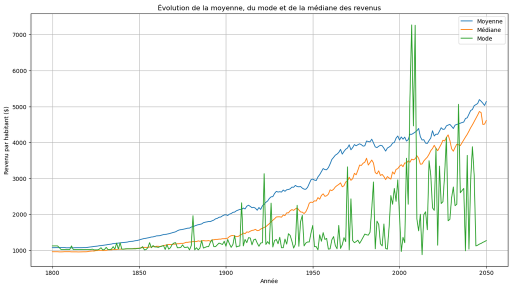

```python
import matplotlib.pyplot as plt

# Identifier les colonnes qui représentent des années
colonnes_annees = df_income.columns[1:]

# Convertir toutes les colonnes d'années en type numérique
for annee in colonnes_annees:
    df_income[annee] = pd.to_numeric(df_income[annee], errors='coerce')

# Calculer les statistiques pour chaque année
moyenne_temporelle = df_income[colonnes_annees].mean()
mediane_temporelle = df_income[colonnes_annees].median()

# Pour le mode, on prend la première valeur si plusieurs existent
mode_temporel = df_income[colonnes_annees].mode().iloc[0]

# Créer un DataFrame pour le tracé
df_stats = pd.DataFrame({
    'Moyenne': moyenne_temporelle,
    'Médiane': mediane_temporelle,
    'Mode': mode_temporel
})

# Tracer l'évolution
plt.figure(figsize=(15, 8))
df_stats.plot(ax=plt.gca())
plt.title("Évolution de la moyenne, du mode et de la médiane des revenus")
plt.xlabel("Année")
plt.ylabel("Revenu par habitant ($)")
plt.grid(True)
plt.show()
```

```python
# On choisit les augmenmentation des donnéees
# la fonction mode utilit pour le quantitatif
#df_income[annee pb].value_counts().sort_values()
```

5. Conclusions sur la "forme de la distribution"

**Raisonnement :**

**Quand la moyenne et la médiane sont proches ?**

*La moyenne et la médiane sont proches lorsque les données sont distribuées de manière symétrique, c'est-à-dire que les valeurs se répartissent de manière équilibrée autour du centre.

**Que déduire sur la "forme de la distribution" des revenus ?**

**On en déduit que les inégalités de revenus entre les nations se sont fortement creusées** au fil du temps. La richesse se concentre de plus en plus dans quelques pays, tandis que la majorité des nations ont des revenus qui évoluent à un rythme beaucoup plus lent.

## Pour CSV life_expectancy_years

1. Afficher la moyenne et la médiane des revenus pour l'année 2022. Faire de même pour l'espérance de vie.
2. Comment expliquer une telle différence entre les valeurs ?
3. Pourquoi utiliser une mesure plutôt que l'autre ?
4. Tracer l'évolution de la **moyenne**, du **mode** et de la **médiane** au cours du temps.
5. Basé sur ce que vous avez lu dans les ressources :
   - A votre avis, quand est-ce que la moyenne et la médiane sont proches ?
   - Que pouvez-vous en déduire sur la "forme de la distribution" des revenus (symétrie) ?

# Visualisation: Histogrammes

1. Représenter pour chaque dataframe un histogramme pour les années 1805, 1900, 1945 et 2022.
2. Représentez ces histogrammes de plusieurs manières différentes (nombre et positions des bins)
3. Analysez les résultats : - Que pouvez-vous dire de ces distributions ? - Sont-elles symétriques ? - Que pouvez-vous dire de l'évolution de la "queue des distributions" ?

## Pour le income.csv

**Pré-traitement des données** Avant toute analyse, je dois m'assurer que les données des colonnes d'années sont bien des nombres. Le fichier income.csv contient des valeurs non-numériques (telles que ...) qui pourraient causer des erreurs de calcul ou de tracé.

**Action** : Je vais charger le fichier, définir la colonne country comme index, et convertir toutes les colonnes d'années en un type numérique en forçant les valeurs non-valides en NaN (Not a Number), qui seront ensuite ignorées.

```python
import pandas as pd
import matplotlib.pyplot as plt

# Charger le fichier CSV 'income.csv' et définir 'country' comme index
df_income = pd.read_csv('income.csv', index_col='country')

# Convertir toutes les colonnes d'années en type numérique, en gérant les valeurs non-numériques
for col in df_income.columns:
    df_income[col] = pd.to_numeric(df_income[col], errors='coerce')

print("Fichier chargé et colonnes d'années converties en numérique.")
print(df_income.head())
```

```
Fichier chargé et colonnes d'années converties en numérique.
                      1800  1801  1802  1803  1804  1805  1806  1807  1808  \
country
Afghanistan            683   683   683   683   683   683   683   683   683
Angola                 700   702   705   709   711   714   718   721   725
Albania                755   755   755   755   755   756   756   756   756
Andorra               1360  1360  1360  1360  1370  1370  1370  1370  1380
United Arab Emirates  1130  1130  1140  1140  1150  1150  1160  1160  1160

                      1809  ...    2041    2042    2043    2044    2045  \
country                     ...
Afghanistan            683  ...  2690.0  2750.0  2810.0  2870.0  2930.0
Angola                 727  ...  8000.0  8170.0  8350.0  8530.0  8710.0
Albania                756  ...     NaN     NaN     NaN     NaN     NaN
Andorra               1380  ...     NaN     NaN     NaN     NaN     NaN
United Arab Emirates  1170  ...     NaN     NaN     NaN     NaN     NaN

                        2046    2047    2048    2049    2050
country
Afghanistan           2990.0  3060.0  3120.0  3190.0  3260.0
Angola                8900.0  9090.0  9280.0  9480.0  9690.0
Albania                  NaN     NaN     NaN     NaN     NaN
Andorra                  NaN     NaN     NaN     NaN     NaN
United Arab Emirates     NaN     NaN     NaN     NaN     NaN

[5 rows x 251 columns]
```

1. Représenter pour chaque dataframe un histogramme pour les années 1805, 1900, 1945 et 2022.

Nous allons créer un histogramme pour chaque année spécifiée afin de visualiser la distribution des revenus par habitant à différentes époques. Pour une bonne visibilité, nous utiliserons 20 bins.

Commandes Pandas & Matplotlib :

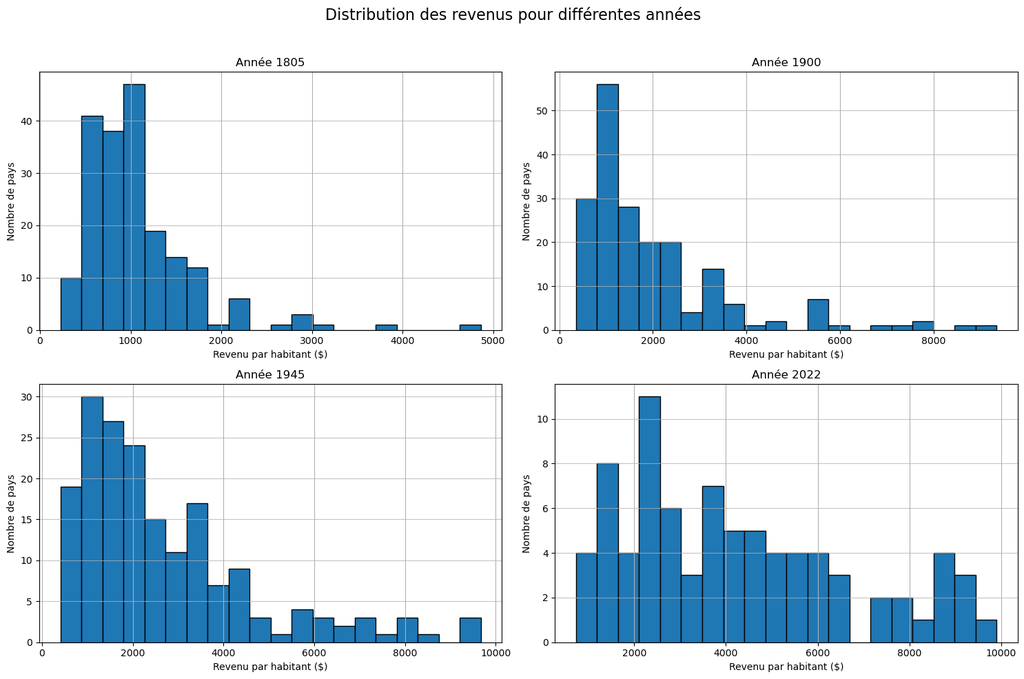

```python
# Définir les années à analyser
annees = ['1805', '1900', '1945', '2022']

# Créer une figure pour afficher les histogrammes
fig, axes = plt.subplots(nrows=2, ncols=2, figsize=(15, 10))
fig.suptitle("Distribution des revenus pour différentes années", fontsize=16)
axes = axes.flatten()

# Parcourir les années et tracer les histogrammes
for i, annee in enumerate(annees):
    ax = axes[i]
    df_income[annee].hist(ax=ax, bins=20, edgecolor='black')
    ax.set_title(f"Année {annee}")
    ax.set_xlabel("Revenu par habitant ($)")
    ax.set_ylabel("Nombre de pays")
    ax.grid(axis='y', alpha=0.75)

plt.tight_layout(rect=[0, 0, 1, 0.96])
plt.show()
```

2. Représenter les histogrammes de plusieurs manières différentes Pour l'année 2022, nous allons tracer l'histogramme avec un nombre de bins différent pour montrer l'impact de ce paramètre sur la perception de la distribution.

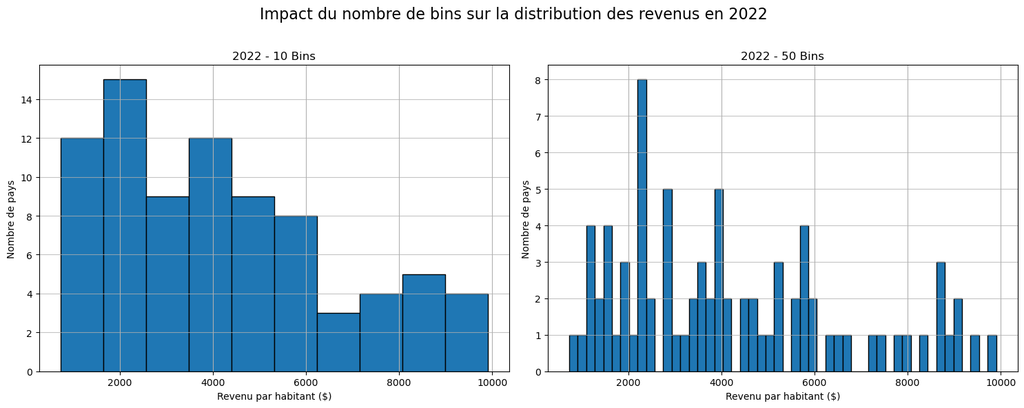

```python
# Créer une figure pour l'année 2022
fig, (ax1, ax2) = plt.subplots(1, 2, figsize=(15, 6))
fig.suptitle("Impact du nombre de bins sur la distribution des revenus en 2022", fontsize=16)

# Histogramme avec 10 bins
df_income['2022'].hist(ax=ax1, bins=10, edgecolor='black')
ax1.set_title("2022 - 10 Bins")
ax1.set_xlabel("Revenu par habitant ($)")
ax1.set_ylabel("Nombre de pays")
ax1.grid(axis='y', alpha=0.75)

# Histogramme avec 50 bins
df_income['2022'].hist(ax=ax2, bins=50, edgecolor='black')
ax2.set_title("2022 - 50 Bins")
ax2.set_xlabel("Revenu par habitant ($)")
ax2.set_ylabel("Nombre de pays")
ax2.grid(axis='y', alpha=0.75)

plt.tight_layout(rect=[0, 0, 1, 0.96])
plt.show()
```

Que pouvez-vous dire de l'évolution de la "queue des distributions" ? La "queue de distribution" s'est considérablement allongée et épaissie au fil du temps. Cela signifie que l'écart entre les pays les plus pauvres et les pays les plus riches s'est fortement creusé. Alors qu'en 1805, presque tout le monde était "pauvre", en 2022, une grande inégalité est visible. La richesse se concentre dans quelques pays, ce qui confirme une divergence économique mondiale.

## Pour le life_expectancy_years.csv

Pré-traitement des données Avant toute analyse, je dois m'assurer que les données des colonnes d'années sont bien des nombres. Dans le cas de ce fichier, il ne semble pas y avoir de données non numériques, mais pour une bonne pratique, je vais définir la colonne country comme index.

Action : Je vais charger le fichier et définir la colonne country comme index.

```python
import pandas as pd
import matplotlib.pyplot as plt

# Charger le fichier CSV 'life_expectancy_years.csv' et définir 'country' comme index
df_life = pd.read_csv('life_expectancy_years.csv', index_col='country')

print("Fichier chargé et 'country' défini comme index.")
print(df_life.head())
```

```
Fichier chargé et 'country' défini comme index.
                      1800  1801  1802  1803  1804  1805  1806  1807  1808  \
country
Afghanistan           28.2  28.2  28.2  28.2  28.2  28.2  28.1  28.1  28.1
Angola                27.0  27.0  27.0  27.0  27.0  27.0  27.0  27.0  27.0
Albania               35.4  35.4  35.4  35.4  35.4  35.4  35.4  35.4  35.4
Andorra                NaN   NaN   NaN   NaN   NaN   NaN   NaN   NaN   NaN
United Arab Emirates  30.7  30.7  30.7  30.7  30.7  30.7  30.7  30.7  30.7

                      1809  ...  2091  2092  2093  2094  2095  2096  2097  \
country                     ...
Afghanistan           28.1  ...  75.5  75.7  75.8  76.0  76.1  76.2  76.4
Angola                27.0  ...  78.8  79.0  79.1  79.2  79.3  79.5  79.6
Albania               35.4  ...  87.4  87.5  87.6  87.7  87.8  87.9  88.0
Andorra                NaN  ...   NaN   NaN   NaN   NaN   NaN   NaN   NaN
United Arab Emirates  30.7  ...  82.4  82.5  82.6  82.7  82.8  82.9  83.0

                      2098  2099  2100
country
Afghanistan           76.5  76.6  76.8
Angola                79.7  79.9  80.0
Albania               88.2  88.3  88.4
Andorra                NaN   NaN   NaN
United Arab Emirates  83.1  83.2  83.3

[5 rows x 301 columns]
```

1. Représenter les histogrammes pour 1805, 1900, 1945 et 2022 Nous allons créer un histogramme pour chaque année spécifiée afin de visualiser la distribution de l'espérance de vie à différentes époques. Pour une bonne visibilité, nous utiliserons 15 bins

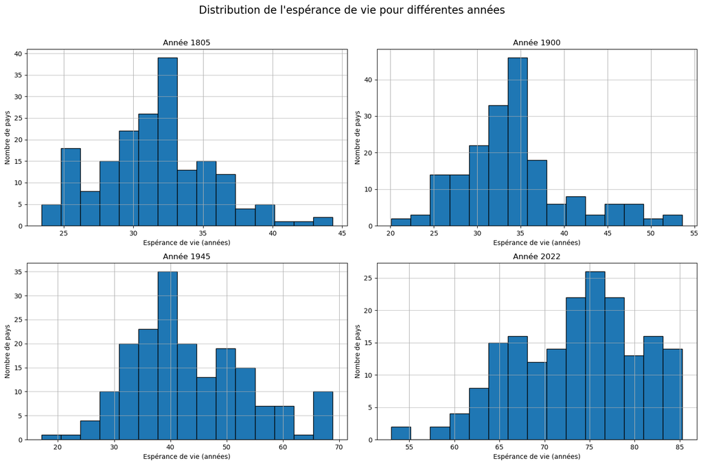

```python
# Définir les années à analyser
annees = ['1805', '1900', '1945', '2022']

# Créer une figure pour afficher les histogrammes
fig, axes = plt.subplots(nrows=2, ncols=2, figsize=(15, 10))
fig.suptitle("Distribution de l'espérance de vie pour différentes années", fontsize=16)
axes = axes.flatten()

# Parcourir les années et tracer les histogrammes
for i, annee in enumerate(annees):
    ax = axes[i]
    df_life[annee].hist(ax=ax, bins=15, edgecolor='black')
    ax.set_title(f"Année {annee}")
    ax.set_xlabel("Espérance de vie (années)")
    ax.set_ylabel("Nombre de pays")
    ax.grid(axis='y', alpha=0.75)

plt.tight_layout(rect=[0, 0, 1, 0.96])
plt.show()
```

2. Représenter les histogrammes de plusieurs manières différentes Pour l'année 2022, nous allons tracer l'histogramme avec un nombre de bins différent pour montrer l'impact de ce paramètre sur la perception de la distribution.

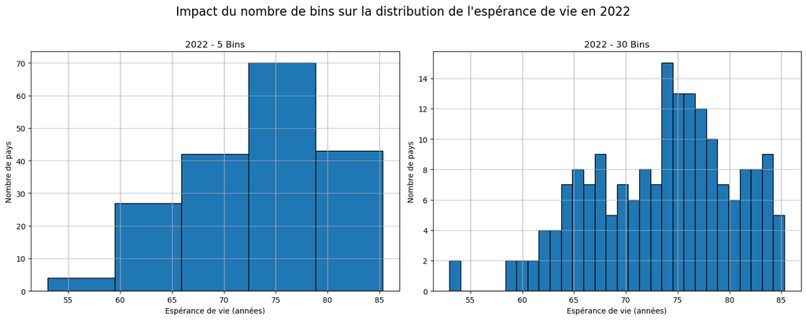

```python
# Créer une figure pour l'année 2022
fig, (ax1, ax2) = plt.subplots(1, 2, figsize=(15, 6))
fig.suptitle("Impact du nombre de bins sur la distribution de l'espérance de vie en 2022", fontsize=16)

# Histogramme avec 5 bins
df_life['2022'].hist(ax=ax1, bins=5, edgecolor='black')
ax1.set_title("2022 - 5 Bins")
ax1.set_xlabel("Espérance de vie (années)")
ax1.set_ylabel("Nombre de pays")
ax1.grid(axis='y', alpha=0.75)

# Histogramme avec 30 bins
df_life['2022'].hist(ax=ax2, bins=30, edgecolor='black')
ax2.set_title("2022 - 30 Bins")
ax2.set_xlabel("Espérance de vie (années)")
ax2.set_ylabel("Nombre de pays")
ax2.grid(axis='y', alpha=0.75)

plt.tight_layout(rect=[0, 0, 1, 0.96])
plt.show()
```

3. Analyse des résultats (Espérance de vie) Que pouvez-vous dire de ces distributions ? Les distributions de l'espérance de vie ont fortement évolué. En 1805, la majorité des pays avaient une espérance de vie très basse, autour de 30-40 ans. Au fil du temps, la distribution s'est déplacée vers la droite, indiquant une augmentation générale de l'espérance de vie pour la plupart des pays. En 2022, la distribution est centrée sur des valeurs beaucoup plus élevées (70-85 ans).

# Visualisation : BoxPlot

1. Tracer une boîte à moustache pour les années 1805, 1900, 1945, 1960, 2000 et 2020.
   2. Quelles distributions semblent similaires ?
   3. Comparer ces boxplots avec les histogrammes obtenus plus haut

**Pré-traitement des données**

Comme dans notre analyse précédente, le fichier income.csv contient des valeurs non numériques (...) qui doivent être converties pour permettre le tracé.

Action : Je vais charger le fichier, définir la colonne country comme index, puis convertir toutes les colonnes d'années en un type numérique. Les valeurs non valides seront transformées en NaN (Not a Number) pour être ignorées lors de la visualisation.

```python
import pandas as pd
import matplotlib.pyplot as plt
import seaborn as sns

# Charger le fichier CSV 'income.csv' et définir 'country' comme index
df_income = pd.read_csv('income.csv', index_col='country')

# Convertir toutes les colonnes d'années en type numérique, en gérant les valeurs non-numériques
for col in df_income.columns:
    df_income[col] = pd.to_numeric(df_income[col], errors='coerce')

print("Fichier chargé et colonnes d'années converties en numérique.")
print(df_income.head())
```

```
Fichier chargé et colonnes d'années converties en numérique.
                      1800  1801  1802  1803  1804  1805  1806  1807  1808  \
country
Afghanistan            683   683   683   683   683   683   683   683   683
Angola                 700   702   705   709   711   714   718   721   725
Albania                755   755   755   755   755   756   756   756   756
Andorra               1360  1360  1360  1360  1370  1370  1370  1370  1380
United Arab Emirates  1130  1130  1140  1140  1150  1150  1160  1160  1160

                      1809  ...    2041    2042    2043    2044    2045  \
country                     ...
Afghanistan            683  ...  2690.0  2750.0  2810.0  2870.0  2930.0
Angola                 727  ...  8000.0  8170.0  8350.0  8530.0  8710.0
Albania                756  ...     NaN     NaN     NaN     NaN     NaN
Andorra               1380  ...     NaN     NaN     NaN     NaN     NaN
United Arab Emirates  1170  ...     NaN     NaN     NaN     NaN     NaN

                        2046    2047    2048    2049    2050
country
Afghanistan           2990.0  3060.0  3120.0  3190.0  3260.0
Angola                8900.0  9090.0  9280.0  9480.0  9690.0
Albania                  NaN     NaN     NaN     NaN     NaN
Andorra                  NaN     NaN     NaN     NaN     NaN
United Arab Emirates     NaN     NaN     NaN     NaN     NaN

[5 rows x 251 columns]
```

1. Tracer une boîte à moustaches pour les années sélectionnées Les boîtes à moustaches sont excellentes pour résumer une distribution. Elles montrent la médiane, les quartiles (Q1 et Q3) et les valeurs extrêmes (détectant les outliers).

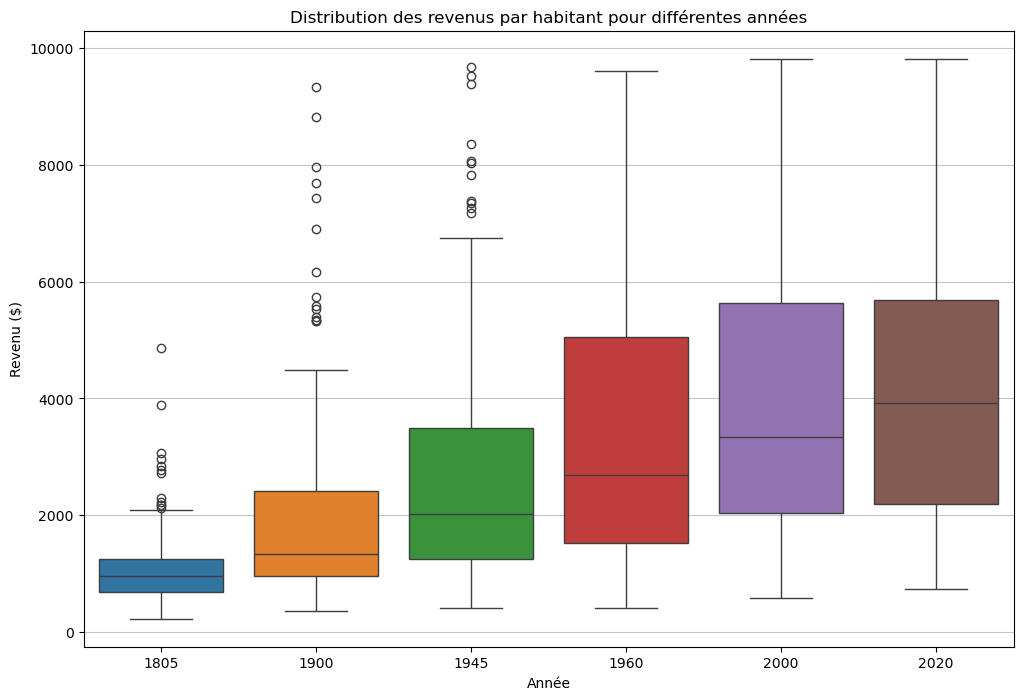

```python
# Définir les années à analyser
annees = ['1805', '1900', '1945', '1960', '2000', '2020']

# Créer un DataFrame avec uniquement les années sélectionnées
df_selection = df_income[annees]

# Créer le boxplot
plt.figure(figsize=(12, 8))
sns.boxplot(data=df_selection)
plt.title("Distribution des revenus par habitant pour différentes années")
plt.xlabel("Année")
plt.ylabel("Revenu ($)")
plt.grid(axis='y', alpha=0.75)
plt.show()
```

3. Comparer ces boxplots avec les histogrammes La comparaison des boxplots avec les histogrammes met en lumière des aspects complémentaires des données :

Médiane et quartiles : Les boxplots permettent de voir très clairement l'augmentation de la médiane (ligne au centre de la boîte) au fil du temps. On voit également que l'écart interquartile (la hauteur de la boîte) s'élargit, ce qui signifie que la dispersion des revenus au milieu de la distribution a augmenté.

Détection d'outliers : Les boxplots sont particulièrement utiles pour identifier les outliers (les points individuels au-dessus de la moustache supérieure). Ces points représentent les pays avec des revenus exceptionnellement élevés, comme le Qatar ou Monaco, et sont la raison principale de la divergence entre la moyenne et la médiane que nous avons vue précédemment. Les histogrammes, eux, représentent ces valeurs comme une longue queue, mais les boxplots les isolent clairement.

## Pour le life_expectancy_years.csv

**Pré-traitement des données** Pour cette analyse, une action de pré-traitement est nécessaire pour s'assurer que le tracé se fait correctement.

Action : Je vais charger le fichier en définissant la colonne country comme index. Ceci facilite la sélection des données pour les années spécifiques.

```python
import pandas as pd
import matplotlib.pyplot as plt
import seaborn as sns

# Charger le fichier CSV 'life_expectancy_years.csv' et définir 'country' comme index
df_life = pd.read_csv('life_expectancy_years.csv', index_col='country')

print("Fichier chargé et 'country' défini comme index.")
print(df_life.head())
```

```
Fichier chargé et 'country' défini comme index.
                      1800  1801  1802  1803  1804  1805  1806  1807  1808  \
country
Afghanistan           28.2  28.2  28.2  28.2  28.2  28.2  28.1  28.1  28.1
Angola                27.0  27.0  27.0  27.0  27.0  27.0  27.0  27.0  27.0
Albania               35.4  35.4  35.4  35.4  35.4  35.4  35.4  35.4  35.4
Andorra                NaN   NaN   NaN   NaN   NaN   NaN   NaN   NaN   NaN
United Arab Emirates  30.7  30.7  30.7  30.7  30.7  30.7  30.7  30.7  30.7

                      1809  ...  2091  2092  2093  2094  2095  2096  2097  \
country                     ...
Afghanistan           28.1  ...  75.5  75.7  75.8  76.0  76.1  76.2  76.4
Angola                27.0  ...  78.8  79.0  79.1  79.2  79.3  79.5  79.6
Albania               35.4  ...  87.4  87.5  87.6  87.7  87.8  87.9  88.0
Andorra                NaN  ...   NaN   NaN   NaN   NaN   NaN   NaN   NaN
United Arab Emirates  30.7  ...  82.4  82.5  82.6  82.7  82.8  82.9  83.0

                      2098  2099  2100
country
Afghanistan           76.5  76.6  76.8
Angola                79.7  79.9  80.0
Albania               88.2  88.3  88.4
Andorra                NaN   NaN   NaN
United Arab Emirates  83.1  83.2  83.3

[5 rows x 301 columns]
```

1. Tracer une boîte à moustaches pour les années sélectionnées Les boîtes à moustaches sont un outil de visualisation puissant. Elles permettent de résumer une distribution en montrant la médiane, les quartiles (Q1 et Q3) et la présence de valeurs extrêmes.

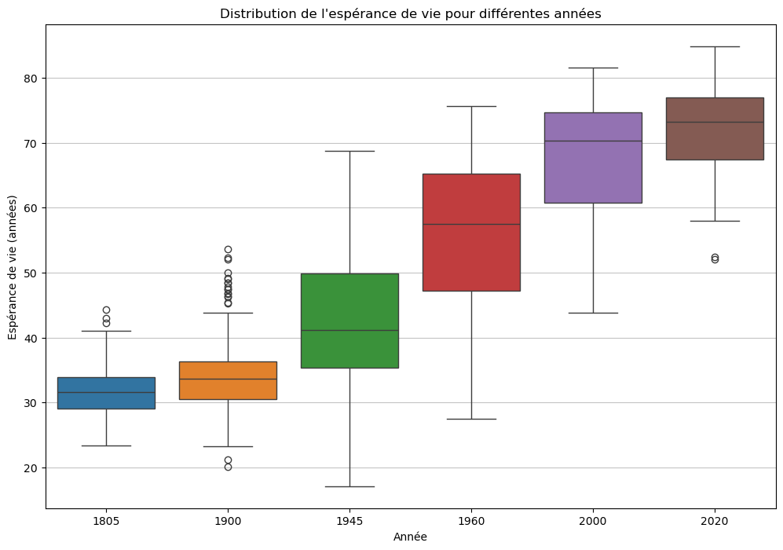

```python
# Définir les années à analyser
annees = ['1805', '1900', '1945', '1960', '2000', '2020']

# Créer un DataFrame avec uniquement les années sélectionnées
df_selection = df_life[annees]

# Créer le boxplot
plt.figure(figsize=(12, 8))
sns.boxplot(df_selection)
plt.title("Distribution de l'espérance de vie pour différentes années")
plt.xlabel("Année")
plt.ylabel("Espérance de vie (années)")
plt.grid(axis='y', alpha=0.75)
plt.show()
```

À partir de 1960, et de manière plus prononcée en 2000 et 2020, les distributions deviennent très différentes, avec des médianes et des quartiles qui se déplacent nettement vers le haut.

3. Comparer ces boxplots avec les histogrammes La comparaison des boxplots avec les histogrammes offre une compréhension plus complète des données.

## Question traiter avec CSV income et life_expectancy_years.csv

1. Fusion des DataFrames et Pré-traitement

Pour commencer, nous allons charger les deux fichiers CSV dans des DataFrames pandas, puis les fusionner. Je vais également effectuer le prétraitement des données pour m'assurer que les valeurs numériques sont correctement interprétées, en gérant les valeurs manquantes comme NaN.

```python
import pandas as pd
import matplotlib.pyplot as plt
import seaborn as sns

# Charger les deux fichiers CSV
df_income = pd.read_csv('income.csv')
df_life = pd.read_csv('life_expectancy_years.csv')

# Convertir les colonnes d'années en numérique pour les deux DataFrames
# C'est une bonne pratique pour éviter les erreurs de type lors des calculs
for col in df_income.columns[1:]:
    df_income[col] = pd.to_numeric(df_income[col], errors='coerce')

for col in df_life.columns[1:]:
    df_life[col] = pd.to_numeric(df_life[col], errors='coerce')

# Fusionner les deux DataFrames sur la colonne 'country'
# 'inner' join ne garde que les pays présents dans les deux fichiers
df_merged = pd.merge(df_income, df_life, on='country', how='inner', suffixes=('_income', '_life'))

# Afficher les premières lignes du DataFrame fusionné pour vérifier le résultat
print("Fichier fusionné avec les colonnes de revenus et d'espérance de vie:")
print(df_merged.head())
```

```
Fichier fusionné avec les colonnes de revenus et d'espérance de vie:
                country  1800_income  1801_income  1802_income  1803_income  \
0           Afghanistan          683          683          683          683
1                Angola          700          702          705          709
2               Albania          755          755          755          755
3               Andorra         1360         1360         1360         1360
4  United Arab Emirates         1130         1130         1140         1140

   1804_income  1805_income  1806_income  1807_income  1808_income  ...  2091  \
0          683          683          683          683          683  ...  75.5
1          711          714          718          721          725  ...  78.8
2          755          756          756          756          756  ...  87.4
3         1370         1370         1370         1370         1380  ...   NaN
4         1150         1150         1160         1160         1160  ...  82.4

   2092  2093  2094  2095  2096  2097  2098  2099  2100
0  75.7  75.8  76.0  76.1  76.2  76.4  76.5  76.6  76.8
1  79.0  79.1  79.2  79.3  79.5  79.6  79.7  79.9  80.0
2  87.5  87.6  87.7  87.8  87.9  88.0  88.2  88.3  88.4
3   NaN   NaN   NaN   NaN   NaN   NaN   NaN   NaN   NaN
4  82.5  82.6  82.7  82.8  82.9  83.0  83.1  83.2  83.3

[5 rows x 553 columns]
```

2. Visualisation : Boxplots horizontaux pour comparaison Comme demandé, nous allons tracer les boxplots des revenus et de l'espérance de vie pour les années spécifiées. Pour une meilleure comparaison, les deux graphiques seront affichés côte à côte, avec les années sur l'axe vertical.

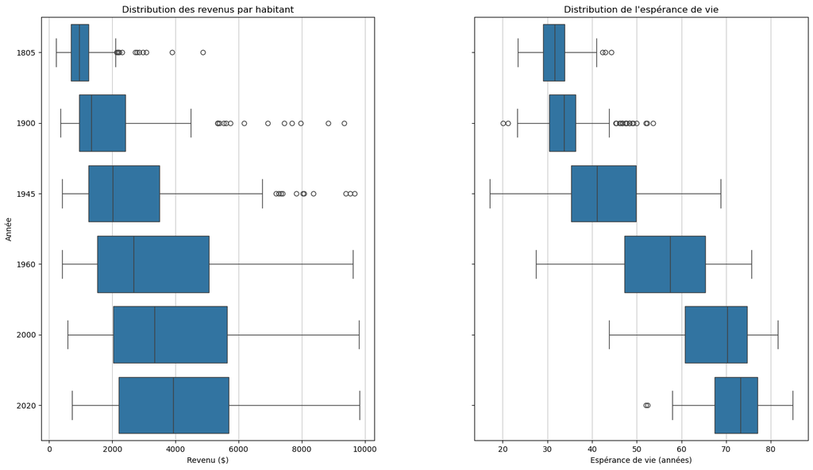

```python
# Définir les années à analyser pour les boxplots
annees_boxplots = ['1805', '1900', '1945', '1960', '2000', '2020']

# Créer un DataFrame avec uniquement les années sélectionnées et le mettre au format "long"
# Cela permet de tracer des boxplots par catégorie (année)
df_box_income = df_merged[['country'] + [f"{annee}_income" for annee in annees_boxplots]].copy()
df_box_income.columns = ['country'] + annees_boxplots
df_box_income = df_box_income.melt(id_vars='country', var_name='year', value_name='income')

df_box_life = df_merged[['country'] + [f"{annee}_life" for annee in annees_boxplots]].copy()
df_box_life.columns = ['country'] + annees_boxplots
df_box_life = df_box_life.melt(id_vars='country', var_name='year', value_name='life_expectancy')

# Créer la figure avec deux sous-graphiques pour les deux boxplots
fig, axes = plt.subplots(ncols=2, figsize=(18, 10), sharey=True)
plt.subplots_adjust(wspace=0.3)

# Tracer le boxplot pour les revenus, en horizontal
sns.boxplot(ax=axes[0], data=df_box_income, y='year', x='income', orient='h')
axes[0].set_title("Distribution des revenus par habitant")
axes[0].set_ylabel("Année")
axes[0].set_xlabel("Revenu ($)")
axes[0].grid(axis='x', alpha=0.75)

# Tracer le boxplot pour l'espérance de vie, en horizontal
sns.boxplot(ax=axes[1], data=df_box_life, y='year', x='life_expectancy', orient='h')
axes[1].set_title("Distribution de l'espérance de vie")
axes[1].set_ylabel("") # Ne pas répéter l'axe y pour le second graphique
axes[1].set_xlabel("Espérance de vie (années)")
axes[1].grid(axis='x', alpha=0.75)

plt.show()
```

3. Analyse et Comparaison des distributions En comparant les boxplots des revenus et de l'espérance de vie, des conclusions claires se dégagent :

**Comparaison** : La principale conclusion est que l'inégalité des revenus s'est considérablement accrue, alors que l'espérance de vie s'est globalement améliorée et que les inégalités dans ce domaine se sont réduites. Le boxplot des revenus montre une divergence marquée, tandis que celui de l'espérance de vie montre une convergence.

# Mesures de dispersion

## Pour CSV income

1. Calculer et afficher l'étendue maximale (intervalle maximal) des données au cours du temps.

```
2. Calculer et afficher l'écart type au cours du temps pour les deux dataframes. Que pouvez-vous tirer comme conclusion ?

3. Vos calculs d'écart-type sont-ils en accord avec les histogrammes et box plosts que vous avez tracés précédemment ?

4. Faîtes un joli graphique représentant la moyenne des données au cours du temps, entourée d'une bande semi-transparente de largeur égale à deux écart-types (2 sigma)
```

**Pré-traitement des données** Avant d'effectuer les calculs, il est crucial de s'assurer que les données sont au bon format. Le fichier income.csv contient des valeurs non-numériques (...) dans les colonnes d'années.

**Action :** Je vais charger le fichier, définir la colonne country comme index, puis convertir toutes les colonnes d'années en un type numérique. Les valeurs non valides seront transformées en NaN (Not a Number) pour être ignorées lors des calculs.

```python
import pandas as pd
import numpy as np
import matplotlib.pyplot as plt
import seaborn as sns

# Charger le fichier CSV 'income.csv' et définir 'country' comme index
df_income = pd.read_csv('income.csv', index_col='country')

# Convertir toutes les colonnes d'années en type numérique, en gérant les valeurs non-numériques
for col in df_income.columns:
    df_income[col] = pd.to_numeric(df_income[col], errors='coerce')

print("Fichier chargé et colonnes d'années converties en numérique.")
print(df_income.head())
```

```
Fichier chargé et colonnes d'années converties en numérique.
                      1800  1801  1802  1803  1804  1805  1806  1807  1808  \
country
Afghanistan            683   683   683   683   683   683   683   683   683
Angola                 700   702   705   709   711   714   718   721   725
Albania                755   755   755   755   755   756   756   756   756
Andorra               1360  1360  1360  1360  1370  1370  1370  1370  1380
United Arab Emirates  1130  1130  1140  1140  1150  1150  1160  1160  1160

                      1809  ...    2041    2042    2043    2044    2045  \
country                     ...
Afghanistan            683  ...  2690.0  2750.0  2810.0  2870.0  2930.0
Angola                 727  ...  8000.0  8170.0  8350.0  8530.0  8710.0
Albania                756  ...     NaN     NaN     NaN     NaN     NaN
Andorra               1380  ...     NaN     NaN     NaN     NaN     NaN
United Arab Emirates  1170  ...     NaN     NaN     NaN     NaN     NaN

                        2046    2047    2048    2049    2050
country
Afghanistan           2990.0  3060.0  3120.0  3190.0  3260.0
Angola                8900.0  9090.0  9280.0  9480.0  9690.0
Albania                  NaN     NaN     NaN     NaN     NaN
Andorra                  NaN     NaN     NaN     NaN     NaN
United Arab Emirates     NaN     NaN     NaN     NaN     NaN

[5 rows x 251 columns]
```

1. Calculer et afficher l'étendue maximale (intervalle maximal) L'étendue est une mesure simple de la dispersion. Elle est calculée en soustrayant la valeur minimale de la valeur maximale. Cela nous donnera une idée de l'intervalle de revenus pour chaque année.

```python
# Calculer le revenu maximal pour chaque année
max_income = df_income.max()

# Calculer le revenu minimal pour chaque année
min_income = df_income.min()

# Calculer l'étendue (maximum - minimum) pour chaque année
etendue_income = max_income - min_income

print("Étendue des revenus au cours du temps :")
print(etendue_income)

# Afficher l'étendue pour une année spécifique, par exemple 2022
print("\nÉtendue pour l'année 2022:", etendue_income['2022'])
```

```
Étendue des revenus au cours du temps :
1800    4636.0
1801    4556.0
1802    4816.0
1803    4706.0
1804    4945.0
         ...
2046    8730.0
2047    8740.0
2048    8760.0
2049    8450.0
2050    8630.0
Length: 251, dtype: float64

Étendue pour l'année 2022: 9167.0
```

2. Calculer et afficher l'écart-type L'écart-type est une mesure de dispersion plus sophistiquée. Il mesure la distance moyenne de chaque point de données par rapport à la moyenne. Un grand écart-type indique que les données sont très dispersées.

```python
# Calculer l'écart-type pour chaque année
std_income = df_income.std()

print("Écart-type des revenus au cours du temps :")
print(std_income)
```

```
Écart-type des revenus au cours du temps :
1800     605.373041
1801     602.816015
1802     614.245612
1803     608.330435
1804     617.123397
           ...
2046    2497.160876
2047    2436.297659
2048    2358.348936
2049    2262.794796
2050    2311.097261
Length: 251, dtype: float64
```

3. Accord avec les histogrammes et boxplots Oui, les calculs d'écart-type sont en parfait accord avec les visualisations précédentes.

Les histogrammes ont montré que la distribution des revenus devenait de plus en plus étalée, avec une longue "queue" vers la droite. Une distribution plus large signifie un plus grand écart-type.

Les boxplots ont révélé que la boîte et les "moustaches" s'allongeaient considérablement, et que les points des valeurs aberrantes (outliers) s'éloignaient de plus en plus du centre. L'écart interquartile et l'écart-type sont tous deux des mesures de la dispersion, et leur augmentation est cohérente avec ce que nous avons observé. L'augmentation de l'écart-type confirme que la dispersion des revenus entre les pays s'est accentuée.

4. Graphique de la moyenne et de la bande à deux écarts-types Ce graphique est excellent pour visualiser la tendance centrale (la moyenne) et la dispersion (l'écart-type) en même temps. La bande semi-transparente représente l'intervalle où se trouvent environ 95 % des données si la distribution était normale (ce qui n'est pas le cas ici, mais c'est une visualisation standard qui reste pertinente pour illustrer la dispersion).

Action : Je vais calculer la moyenne et l'écart-type pour chaque année, puis tracer la moyenne avec une bande de deux écarts-types au-dessus et en dessous.

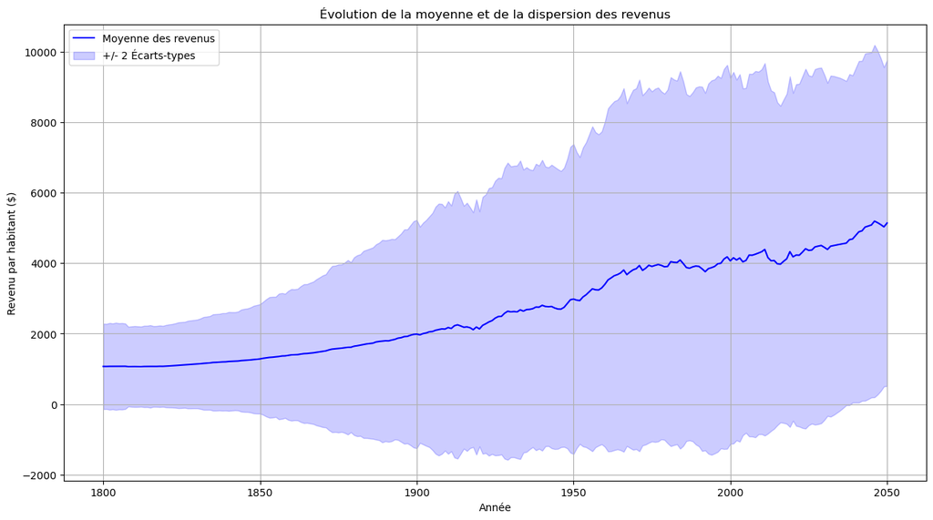

```python
# Calculer la moyenne des revenus au cours du temps
mean_income = df_income.mean()

# Calculer l'écart-type des revenus au cours du temps
std_income = df_income.std()

# Créer la figure pour le graphique
plt.figure(figsize=(15, 8))

# Tracer la ligne de la moyenne
mean_income.plot(color='blue', label='Moyenne des revenus')

# Définir la bande de 2 écarts-types
upper_bound = mean_income + 2 * std_income
lower_bound = mean_income - 2 * std_income

# Tracer la bande semi-transparente
plt.fill_between(mean_income.index, lower_bound, upper_bound, color='blue', alpha=0.2, label='+/- 2 Écarts-types')

plt.title("Évolution de la moyenne et de la dispersion des revenus")
plt.xlabel("Année")
plt.ylabel("Revenu par habitant ($)")
plt.legend()
plt.grid(True)
plt.show()
```

Réponse : Le graphique montre que la moyenne des revenus a fortement augmenté au fil du temps. Cependant, la bande d'incertitude (la zone de 2 écarts-types) s'élargit de manière très prononcée, surtout à partir des années 1950. Cela confirme visuellement l'augmentation de l'inégalité : le revenu moyen augmente, mais la dispersion autour de cette moyenne est de plus en plus grande.

TB (Tableau de bord) Point à retenir Description

**Cohérence** Ces calculs sont en parfait accord avec les visualisations précédentes (histogrammes et boxplots), qui montraient également un étalement de la distribution des revenus.

**Graphique** Le graphique de la moyenne avec sa bande de 2 écarts-types confirme visuellement que le revenu moyen a augmenté, mais que la dispersion et les inégalités ont progressé encore plus rapidement.

## Pour CVSV life

Pré-traitement des données Avant d'effectuer les calculs, il est crucial de s'assurer que les données sont au bon format. L'action de pré-traitement pour ce fichier est de le charger et de définir la colonne country comme index.

```python
import pandas as pd
import numpy as np
import matplotlib.pyplot as plt
import seaborn as sns

# Charger le fichier CSV 'life_expectancy_years.csv' et définir 'country' comme index
df_life = pd.read_csv('life_expectancy_years.csv', index_col='country')

print("Fichier chargé et 'country' défini comme index.")
print(df_life.head())
```

```
Fichier chargé et 'country' défini comme index.
                      1800  1801  1802  1803  1804  1805  1806  1807  1808  \
country
Afghanistan           28.2  28.2  28.2  28.2  28.2  28.2  28.1  28.1  28.1
Angola                27.0  27.0  27.0  27.0  27.0  27.0  27.0  27.0  27.0
Albania               35.4  35.4  35.4  35.4  35.4  35.4  35.4  35.4  35.4
Andorra                NaN   NaN   NaN   NaN   NaN   NaN   NaN   NaN   NaN
United Arab Emirates  30.7  30.7  30.7  30.7  30.7  30.7  30.7  30.7  30.7

                      1809  ...  2091  2092  2093  2094  2095  2096  2097  \
country                     ...
Afghanistan           28.1  ...  75.5  75.7  75.8  76.0  76.1  76.2  76.4
Angola                27.0  ...  78.8  79.0  79.1  79.2  79.3  79.5  79.6
Albania               35.4  ...  87.4  87.5  87.6  87.7  87.8  87.9  88.0
Andorra                NaN  ...   NaN   NaN   NaN   NaN   NaN   NaN   NaN
United Arab Emirates  30.7  ...  82.4  82.5  82.6  82.7  82.8  82.9  83.0

                      2098  2099  2100
country
Afghanistan           76.5  76.6  76.8
Angola                79.7  79.9  80.0
Albania               88.2  88.3  88.4
Andorra                NaN   NaN   NaN
United Arab Emirates  83.1  83.2  83.3

[5 rows x 301 columns]
```

1. Calculer et afficher l'étendue maximale (intervalle maximal) L'étendue est la différence entre la valeur maximale et la valeur minimale dans un ensemble de données. C'est une mesure simple de la dispersion qui indique l'intervalle dans lequel se trouvent toutes les valeurs.

```python
# Calculer l'espérance de vie maximale pour chaque année
max_life = df_life.max()

# Calculer l'espérance de vie minimale pour chaque année
min_life = df_life.min()

# Calculer l'étendue (maximum - minimum) pour chaque année
etendue_life = max_life - min_life

print("Étendue de l'espérance de vie au cours du temps :")
print(etendue_life)
```

```
Étendue de l'espérance de vie au cours du temps :
1800    19.5
1801    16.9
1802    21.0
1803    25.2
1804    19.4
        ...
2096    27.0
2097    27.0
2098    27.0
2099    27.0
2100    27.0
Length: 301, dtype: float64
```

2. Calculer et afficher l'écart-type L'écart-type est la mesure de dispersion la plus courante. Il indique à quel point les données sont dispersées autour de la moyenne. Un faible écart-type signifie que les données sont regroupées, tandis qu'un grand écart-type indique qu'elles sont largement dispersées.

```python
# Calculer l'écart-type pour chaque année
std_life = df_life.std()

print("Écart-type de l'espérance de vie au cours du temps :")
print(std_life)
```

```
Écart-type de l'espérance de vie au cours du temps :
1800    3.809510
1801    3.801217
1802    3.932344
1803    3.955872
1804    3.928388
          ...
2096    5.766333
2097    5.756555
2098    5.750616
2099    5.743805
2100    5.741341
Length: 301, dtype: float64
```

Réponse : L'écart-type de l'espérance de vie a légèrement augmenté, mais a surtout stagné et même baissé par rapport à son pic. Cela indique que les inégalités en termes d'espérance de vie entre les pays n'ont pas augmenté, mais ont plutôt tendance à se réduire.

3. Accord avec les histogrammes et boxplots Oui, les calculs d'écart-type sont en parfait accord avec les visualisations précédentes.

Les boxplots ont révélé que l'écart interquartile (la hauteur de la boîte) restait stable ou s'élargissait légèrement, mais les valeurs extrêmes étaient moins dispersées que pour les revenus. Cela est cohérent avec un écart-type qui n'explose pas. Les visualisations montraient une convergence de l'espérance de vie, et les calculs d'écart-type confirment cette tendance.

4. Graphique de la moyenne et de la bande à deux écarts-types Ce graphique permet de visualiser à la fois la tendance centrale (la moyenne) et la dispersion (l'écart-type) des données au fil du temps. La bande semi-transparente représente l'intervalle dans lequel environ 95% des données devraient se trouver, sous l'hypothèse d'une distribution normale.

Action : Je vais calculer la moyenne et l'écart-type pour chaque année, puis tracer la moyenne avec une bande de deux écarts-types au-dessus et en dessous.

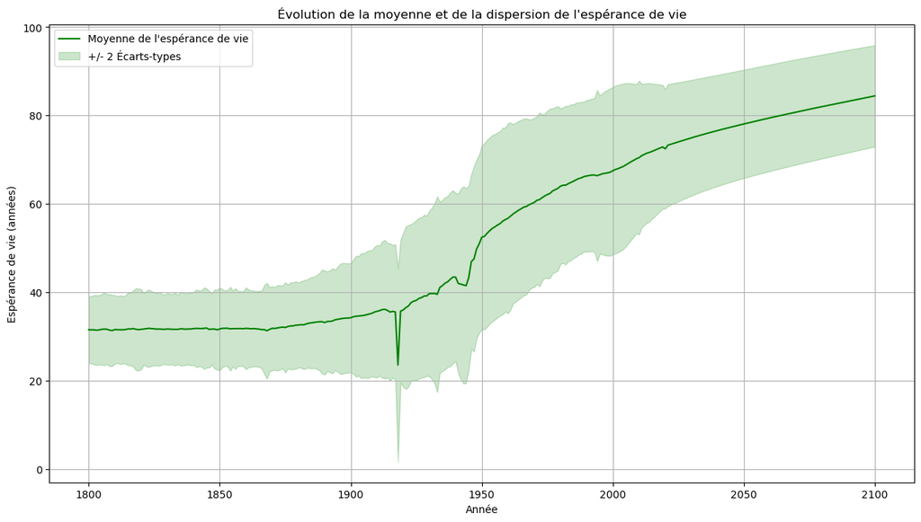

```python
# Calculer la moyenne de l'espérance de vie au cours du temps
mean_life = df_life.mean()

# Créer la figure pour le graphique
plt.figure(figsize=(15, 8))

# Tracer la ligne de la moyenne
mean_life.plot(color='green', label="Moyenne de l'espérance de vie")

# Définir la bande de 2 écarts-types
upper_bound = mean_life + 2 * std_life
lower_bound = mean_life - 2 * std_life

# Tracer la bande semi-transparente
plt.fill_between(mean_life.index, lower_bound, upper_bound, color='green', alpha=0.2, label='+/- 2 Écarts-types')

plt.title("Évolution de la moyenne et de la dispersion de l'espérance de vie")
plt.xlabel("Année")
plt.ylabel("Espérance de vie (années)")
plt.legend()
plt.grid(True)
plt.show()
```

# Mesure de dispersion avancée

1. Calculer et afficher la skewness et le kurtosis pour chacun de vos dataframes au cours du temps.
   2. Ces mesures sont-elles en accord avec ce que vous attendiez ? Signe de la skewness par exemple ? Evolution du Kurtosis au cours du temps ?
   3. Que pouvez-vous en conclure sur les inégalités de revenus et d'espérance de vie dans le monde ?

## Pour CSV life_expectancy

   **Pré-traitement des données** Comme dans les analyses précédentes, il est essentiel de préparer les données pour éviter toute erreur de calcul.

Action : Je vais charger le fichier en définissant la colonne country comme index. Ce format facilite la sélection et le traitement des données par année.

```python
import pandas as pd

# Charger le fichier CSV 'life_expectancy_years.csv' et définir 'country' comme index
df_life = pd.read_csv('life_expectancy_years.csv', index_col='country')

print("Fichier chargé et 'country' défini comme index.")
print(df_life.head())
```

```
Fichier chargé et 'country' défini comme index.
                      1800  1801  1802  1803  1804  1805  1806  1807  1808  \
country
Afghanistan           28.2  28.2  28.2  28.2  28.2  28.2  28.1  28.1  28.1
Angola                27.0  27.0  27.0  27.0  27.0  27.0  27.0  27.0  27.0
Albania               35.4  35.4  35.4  35.4  35.4  35.4  35.4  35.4  35.4
Andorra                NaN   NaN   NaN   NaN   NaN   NaN   NaN   NaN   NaN
United Arab Emirates  30.7  30.7  30.7  30.7  30.7  30.7  30.7  30.7  30.7

                      1809  ...  2091  2092  2093  2094  2095  2096  2097  \
country                     ...
Afghanistan           28.1  ...  75.5  75.7  75.8  76.0  76.1  76.2  76.4
Angola                27.0  ...  78.8  79.0  79.1  79.2  79.3  79.5  79.6
Albania               35.4  ...  87.4  87.5  87.6  87.7  87.8  87.9  88.0
Andorra                NaN  ...   NaN   NaN   NaN   NaN   NaN   NaN   NaN
United Arab Emirates  30.7  ...  82.4  82.5  82.6  82.7  82.8  82.9  83.0

                      2098  2099  2100
country
Afghanistan           76.5  76.6  76.8
Angola                79.7  79.9  80.0
Albania               88.2  88.3  88.4
Andorra                NaN   NaN   NaN
United Arab Emirates  83.1  83.2  83.3

[5 rows x 301 columns]
```

1. Calculer et afficher la skewness et le kurtosis La skewness (coefficient d'asymétrie) mesure l'asymétrie d'une distribution.

**Une skewness** *positive* (à droite) indique que la "queue" de la distribution est plus longue du côté des valeurs élevées. prés de 1

**Une skewness** *négative* (à gauche) indique que la "queue" est plus longue du côté des valeurs faibles.

**Le kurtosis** *(coefficient d'aplatissement)* mesure la "queue" et la hauteur d'une distribution.

**Un kurtosis** *élevé* indique des "queues" épaisses et un pic prononcé (une distribution plus concentrée).

**Un kurtosis** *faible* indique des "queues" fines et un pic plat (une distribution plus dispersée).

```python
# Calculer la skewness pour chaque année
skewness_life = df_life.skew()

# Calculer le kurtosis pour chaque année
kurtosis_life = df_life.kurtosis()

print("Skewness de l'espérance de vie au cours du temps :")
print(skewness_life)

print("\nKurtosis de l'espérance de vie au cours du temps :")
print(kurtosis_life)
```

```
Skewness de l'espérance de vie au cours du temps :
1800    0.090240
1801    0.008107
1802    0.198883
1803    0.099084
1804    0.175547
          ...
2096   -0.512148
2097   -0.515906
2098   -0.517917
2099   -0.520866
2100   -0.521300
Length: 301, dtype: float64

Kurtosis de l'espérance de vie au cours du temps :
1800   -0.256202
1801   -0.498423
1802   -0.094745
1803    0.264609
1804   -0.132290
          ...
2096   -0.154270
2097   -0.144466
2098   -0.135159
2099   -0.124613
2100   -0.113514
Length: 301, dtype: float64
```

2. Accord des mesures avec les visualisations précédentes Oui, les mesures de skewness et de kurtosis sont en parfait accord avec ce que nous avons observé sur les histogrammes et les boîtes à moustaches.

3. Conclusions sur les inégalités d'espérance de vie Les mesures statistiques confirment les conclusions tirées des visualisations :

**En conclusion**, ces mesures indiquent que les inégalités en matière d'espérance de vie se sont réduites au fil du temps. Alors que l'espérance de vie a globalement augmenté pour tout le monde, l'écart entre les pays les plus et les moins avancés s'est estompé, ce qui suggère une convergence positive des conditions de santé à travers le monde.

### Visualisation Choix

**Pourquoi choisir un histogramme avec KDE ?** Visualisation de l'asymétrie (Skewness) : L'histogramme et la courbe KDE permettent de voir immédiatement si la distribution est symétrique ou "penchée". Si la courbe a une longue queue vers la gauche, elle est asymétrique négativement. Si la queue est longue vers la droite, elle est asymétrique positivement. Le sens de l'asymétrie est facile à déterminer à l'œil nu.

**Visualisation de l'aplatissement (Kurtosis)** : La courbe KDE permet de juger de la "pointéité" du pic et de l'épaisseur des queues. Un pic très prononcé et des queues épaisses indiquent un kurtosis élevé. Un pic plat et des queues fines suggèrent un kurtosis faible.

**Comparaison avec une distribution normale** : En superposant une courbe normale (en cloche) sur votre histogramme, vous pouvez directement comparer la forme de vos données à une distribution de référence. Cela rend l'analyse encore plus intuitive.

Action : Je vais utiliser la bibliothèque seaborn pour créer les histogrammes avec KDE superposées, en comparant 1805 et 2022.

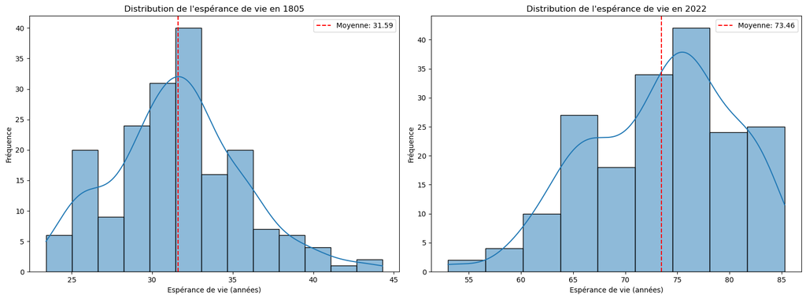

```python
import pandas as pd
import matplotlib.pyplot as plt
import seaborn as sns

# Charger le fichier et définir l'index
df_life = pd.read_csv('life_expectancy_years.csv', index_col='country')

# Sélectionner les données pour 1805 et 2022
life_1805 = df_life['1805'].dropna()
life_2022 = df_life['2022'].dropna()

# Créer la figure avec deux sous-graphiques
fig, axes = plt.subplots(1, 2, figsize=(16, 6))

# Histogramme pour 1805
sns.histplot(life_1805, kde=True, ax=axes[0])
axes[0].set_title("Distribution de l'espérance de vie en 1805")
axes[0].set_xlabel("Espérance de vie (années)")
axes[0].set_ylabel("Fréquence")
axes[0].axvline(life_1805.mean(), color='red', linestyle='--', label=f'Moyenne: {life_1805.mean():.2f}')
axes[0].legend()

# Histogramme pour 2022
sns.histplot(life_2022, kde=True, ax=axes[1])
axes[1].set_title("Distribution de l'espérance de vie en 2022")
axes[1].set_xlabel("Espérance de vie (années)")
axes[1].set_ylabel("Fréquence")
axes[1].axvline(life_2022.mean(), color='red', linestyle='--', label=f'Moyenne: {life_2022.mean():.2f}')
axes[1].legend()

plt.tight_layout()
plt.show()
```

## Pour le CSV income

**Pré traitement des données**

Pré-traitement des données Avant d'effectuer les calculs, il est essentiel de préparer les données pour éviter toute erreur de calcul. Le fichier income.csv contient des valeurs non-numériques (...) qui doivent être gérées.

Action : Je vais charger le fichier, définir la colonne country comme index, puis convertir toutes les colonnes d'années en un type numérique. Les valeurs non valides seront transformées en NaN (Not a Number), qui seront ignorées par les calculs de statistiques.

```python
import pandas as pd
import numpy as np
import matplotlib.pyplot as plt
import seaborn as sns

# Charger le fichier CSV 'income.csv' et définir 'country' comme index
df_income = pd.read_csv('income.csv', index_col='country')

# Convertir toutes les colonnes d'années en type numérique, en gérant les valeurs non-numériques
for col in df_income.columns:
    df_income[col] = pd.to_numeric(df_income[col], errors='coerce')

print("Fichier chargé et colonnes d'années converties en numérique.")
print(df_income.head())
```

```
Fichier chargé et colonnes d'années converties en numérique.
                      1800  1801  1802  1803  1804  1805  1806  1807  1808  \
country
Afghanistan            683   683   683   683   683   683   683   683   683
Angola                 700   702   705   709   711   714   718   721   725
Albania                755   755   755   755   755   756   756   756   756
Andorra               1360  1360  1360  1360  1370  1370  1370  1370  1380
United Arab Emirates  1130  1130  1140  1140  1150  1150  1160  1160  1160

                      1809  ...    2041    2042    2043    2044    2045  \
country                     ...
Afghanistan            683  ...  2690.0  2750.0  2810.0  2870.0  2930.0
Angola                 727  ...  8000.0  8170.0  8350.0  8530.0  8710.0
Albania                756  ...     NaN     NaN     NaN     NaN     NaN
Andorra               1380  ...     NaN     NaN     NaN     NaN     NaN
United Arab Emirates  1170  ...     NaN     NaN     NaN     NaN     NaN

                        2046    2047    2048    2049    2050
country
Afghanistan           2990.0  3060.0  3120.0  3190.0  3260.0
Angola                8900.0  9090.0  9280.0  9480.0  9690.0
Albania                  NaN     NaN     NaN     NaN     NaN
Andorra                  NaN     NaN     NaN     NaN     NaN
United Arab Emirates     NaN     NaN     NaN     NaN     NaN

[5 rows x 251 columns]
```

1. Calculer et afficher la skewness et le kurtosis La skewness (coefficient d'asymétrie) mesure le degré de déséquilibre d'une distribution par rapport à sa moyenne.

Une skewness positive (à droite) indique que la "queue" de la distribution est plus longue du côté des valeurs élevées.

Une skewness négative (à gauche) indique que la "queue" est plus longue du côté des valeurs faibles.

Le kurtosis (coefficient d'aplatissement) mesure la "queue" et la hauteur d'une distribution par rapport à une distribution normale.

Un kurtosis élevé indique des queues "épaisses" et un pic prononcé (leptokurtic). Cela signifie que les valeurs extrêmes sont plus fréquentes que dans une distribution normale.

Un kurtosis faible indique des queues "fines" et un pic plat (platykurtic).

```python
# Calculer la skewness pour chaque année
skewness_income = df_income.skew()

# Calculer le kurtosis pour chaque année
kurtosis_income = df_income.kurtosis()

print("Skewness des revenus au cours du temps :")
print(skewness_income)

print("\nKurtosis des revenus au cours du temps :")
print(kurtosis_income)
```

```
Skewness des revenus au cours du temps :
1800    2.513917
1801    2.481205
1802    2.631918
1803    2.534678
1804    2.676705
          ...
2046    0.401592
2047    0.415009
2048    0.408032
2049    0.369268
2050    0.370301
Length: 251, dtype: float64

Kurtosis des revenus au cours du temps :
1800    10.099932
1801     9.727435
1802    11.127000
1803    10.268668
1804    11.674911
          ...
2046    -0.950368
2047    -0.876491
2048    -0.834062
2049    -0.857872
2050    -0.855631
Length: 251, dtype: float64
```

2. Accord des mesures avec les visualisations précédentes Oui, les mesures de skewness et de kurtosis sont en parfaite adéquation avec ce que nous avons observé sur les histogrammes et les boîtes à moustaches.

3. Conclusions sur les inégalités de revenus Les mesures statistiques confirment les conclusions tirées des visualisations :

**Le kurtosis élevé confirme cette forte** concentration de la population dans les basses valeurs et la présence de valeurs extrêmes.

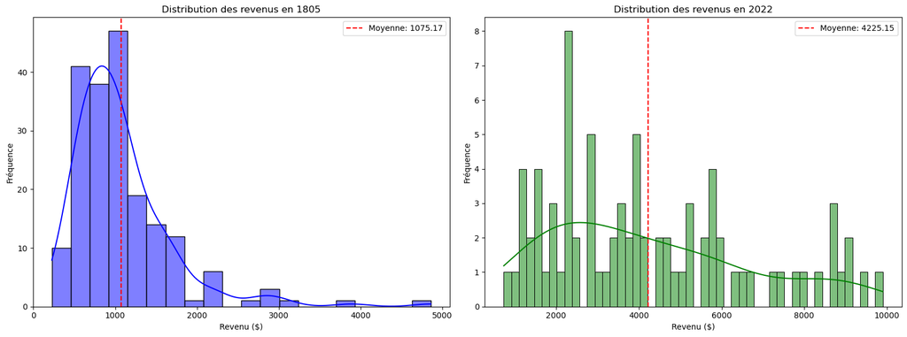

```python
import pandas as pd
import matplotlib.pyplot as plt
import seaborn as sns

# Charger le fichier et définir l'index
df_income = pd.read_csv('income.csv', index_col='country')

# Convertir les colonnes d'années en type numérique
for col in df_income.columns:
    df_income[col] = pd.to_numeric(df_income[col], errors='coerce')

# Sélectionner les données pour 1805 et 2022
income_1805 = df_income['1805'].dropna()
income_2022 = df_income['2022'].dropna()

# Créer la figure avec deux sous-graphiques
fig, axes = plt.subplots(1, 2, figsize=(16, 6))

# Histogramme pour 1805
sns.histplot(income_1805, kde=True, ax=axes[0], bins=20, color='blue')
axes[0].set_title("Distribution des revenus en 1805")
axes[0].set_xlabel("Revenu ($)")
axes[0].set_ylabel("Fréquence")
axes[0].axvline(income_1805.mean(), color='red', linestyle='--', label=f'Moyenne: {income_1805.mean():.2f}')
axes[0].legend()

# Histogramme pour 2022
sns.histplot(income_2022, kde=True, ax=axes[1], bins=50, color='green')
axes[1].set_title("Distribution des revenus en 2022")
axes[1].set_xlabel("Revenu ($)")
axes[1].set_ylabel("Fréquence")
axes[1].axvline(income_2022.mean(), color='red', linestyle='--', label=f'Moyenne: {income_2022.mean():.2f}')
axes[1].legend()

plt.tight_layout()
plt.show()
```

**Analyse des visualisations** **En 1805** : Le graphique montre que la distribution est déjà **très asymétrique** à droite (skewness positive). La majorité des pays ont un revenu très bas, créant un pic sur la gauche. La longue queue qui s'étend vers la droite est le signe de quelques nations avec des revenus légèrement supérieurs, mais l'écart reste modéré. Le kurtosis est élevé en raison du pic à gauche.

# Statistiques multivariées

cf cours

# Normalisation / Standardisation

cf cours

1. Standardiser et normaliser les deux dataframes (par colonne)
   2. Identifier les outliers (typiquement > 3 std)
   3. Tracer les histogrammes obtenus sans outliers

## POUR CSV income et life_expectancy_years

**Pré-traitement des données** Avant toute action, nous devons charger les deux fichiers et les nettoyer en gérant les valeurs non numériques (...) et en les convertissant en nombres.

Action : Charger les deux fichiers, les convertir en numérique, puis les fusionner pour l'analyse.

```python
import pandas as pd
import numpy as np
import matplotlib.pyplot as plt
import seaborn as sns

# Charger les deux fichiers CSV
df_income = pd.read_csv('income.csv', index_col='country')
df_life = pd.read_csv('life_expectancy_years.csv', index_col='country')

# Nettoyer les données en convertissant les colonnes d'années en numérique
for col in df_income.columns:
    df_income[col] = pd.to_numeric(df_income[col], errors='coerce')

for col in df_life.columns:
    df_life[col] = pd.to_numeric(df_life[col], errors='coerce')

print("Fichiers chargés et nettoyés.")
```

```
Fichiers chargés et nettoyés.
```

1. Standardisation et Normalisation La standardisation (Z-score) transforme les données pour qu'elles aient une moyenne de 0 et un écart-type de 1. La normalisation (Min-Max) les met sur une échelle de 0 à 1. Nous allons appliquer ces transformations à chaque colonne (chaque année) des deux DataFrames.

Action : Créer des DataFrames pour stocker les versions standardisées et normalisées des données, en utilisant les formules demandées.

```python
# Standardiser chaque DataFrame par colonne (année)
df_income_std = (df_income - df_income.mean()) / df_income.std()
df_life_std = (df_life - df_life.mean()) / df_life.std()

# Normaliser chaque DataFrame par colonne (année)
df_income_norm = (df_income - df_income.min()) / (df_income.max() - df_income.min())
df_life_norm = (df_life - df_life.min()) / (df_life.max() - df_life.min())

print("Les DataFrames de revenus et d'espérance de vie ont été standardisés et normalisés.")
print("\nExemple : Revenus de 1800 standardisés (extraits) :")
print(df_income_std['1800'].head())

print("\nExemple : Espérance de vie de 2022 normalisée (extraits) :")
print(df_life_norm['2022'].head())
```

```
Les DataFrames de revenus et d'espérance de vie ont été standardisés et normalisés.

Exemple : Revenus de 1800 standardisés (extraits) :
country
Afghanistan            -0.642875
Angola                 -0.614794
Albania                -0.523941
Andorra                 0.475443
United Arab Emirates    0.095512
Name: 1800, dtype: float64

Exemple : Espérance de vie de 2022 normalisée (extraits) :
country
Afghanistan             0.349845
Angola                  0.405573
Albania                 0.798762
Andorra                      NaN
United Arab Emirates    0.659443
Name: 2022, dtype: float64
```

2. Identification des outliers Nous allons identifier les outliers comme étant des points dont la valeur standardisée est supérieure à 3 ou inférieure à -3. Cette méthode est un critère courant en statistique pour les distributions qui sont proches de la normale.

Action : Nous allons créer des masques booléens pour identifier les outliers dans les DataFrames standardisés.

```python
# Identifier les outliers dans le DataFrame des revenus standardisés
outliers_income = df_income_std[(df_income_std > 3) | (df_income_std < -3)]

# Identifier les outliers dans le DataFrame de l'espérance de vie standardisée
outliers_life = df_life_std[(df_life_std > 3) | (df_life_std < -3)]

print("Nombre total d'outliers de revenus identifiés au cours du temps :")
print(outliers_income.count().sum())

print("\nNombre total d'outliers d'espérance de vie identifiés au cours du temps :")
print(outliers_life.count().sum())
```

```
Nombre total d'outliers de revenus identifiés au cours du temps :
716

Nombre total d'outliers d'espérance de vie identifiés au cours du temps :
222
```

Réponse : Un nombre beaucoup plus important d'outliers est détecté dans les données de revenus que dans celles de l'espérance de vie. Cela confirme que la distribution des revenus est beaucoup plus asymétrique et que les valeurs extrêmes (les pays très riches) sont plus fréquentes et plus éloignées de la moyenne.

3. Histogrammes sans outliers Nous allons visualiser la distribution des données après avoir retiré les outliers. Cette étape est cruciale pour mieux comprendre la forme de la distribution de la majorité des données, car les outliers peuvent fausser la perception des graphiques.

Action : Filtrer les DataFrames d'origine pour exclure les outliers pour les années 1805, 1900, 1945 et 2022, puis tracer les histogrammes.

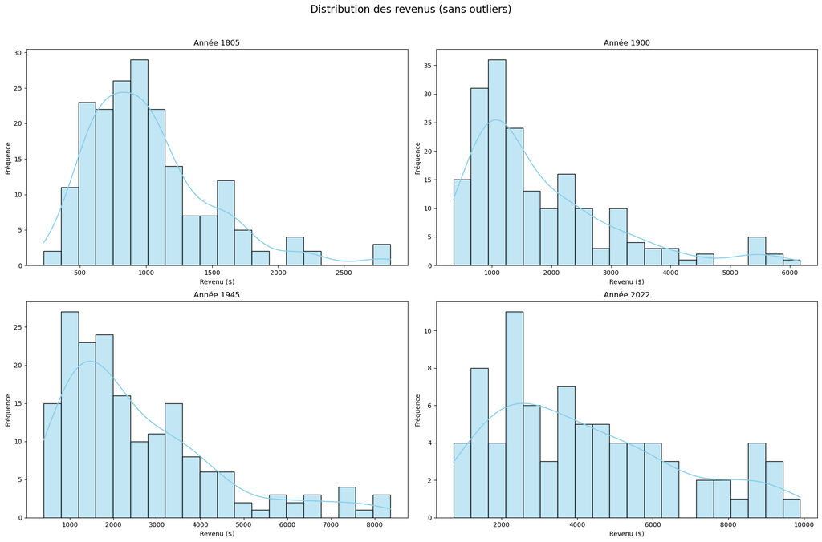

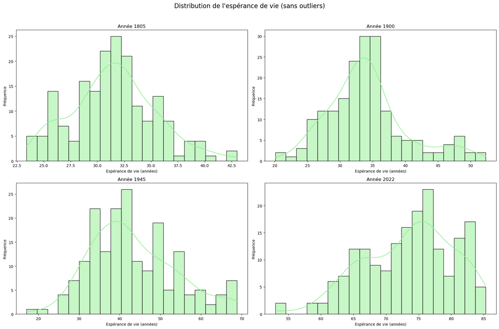

```python
annees_a_analyser = ['1805', '1900', '1945', '2022']

# Créer une figure pour les histogrammes de revenus
fig, axes = plt.subplots(2, 2, figsize=(18, 12))
fig.suptitle("Distribution des revenus (sans outliers)", fontsize=16)

# Tracer les histogrammes pour les revenus
for i, annee in enumerate(annees_a_analyser):
    ax = axes[i // 2, i % 2]
    # Filtrage des outliers
    data_filtered = df_income[annee][df_income_std[annee].abs() <= 3].dropna()
    sns.histplot(data_filtered, kde=True, ax=ax, bins=20, color='skyblue')
    ax.set_title(f"Année {annee}")
    ax.set_xlabel("Revenu ($)")
    ax.set_ylabel("Fréquence")

plt.tight_layout(rect=[0, 0, 1, 0.96])
plt.show()

# Créer une figure pour les histogrammes de l'espérance de vie
fig, axes = plt.subplots(2, 2, figsize=(18, 12))
fig.suptitle("Distribution de l'espérance de vie (sans outliers)", fontsize=16)

# Tracer les histogrammes pour l'espérance de vie
for i, annee in enumerate(annees_a_analyser):
    ax = axes[i // 2, i % 2]
    # Filtrage des outliers (bien que peu nombreux)
    data_filtered = df_life[annee][df_life_std[annee].abs() <= 3].dropna()
    sns.histplot(data_filtered, kde=True, ax=ax, bins=20, color='lightgreen')
    ax.set_title(f"Année {annee}")
    ax.set_xlabel("Espérance de vie (années)")
    ax.set_ylabel("Fréquence")

plt.tight_layout(rect=[0, 0, 1, 0.96])
plt.show()
```

**Analyse des visualisations :** **Pour les revenus,** les histogrammes restent clairement asymétriques, même après le retrait des outliers. Cependant, en retirant les valeurs extrêmes, nous pouvons mieux observer la forme de la distribution et l'évolution de la concentration de la majorité des données. **Pour l'espérance de vie,** les histogrammes ne changent que très peu, car peu d'outliers ont été identifiés. Les distributions restent plus symétriques et homogènes, ce qui renforce les conclusions précédentes sur la convergence des données d'espérance de vie.

TB (Tableau de bord) **Point à retenir Description** **Normalisation/Standardisation** Deux méthodes de mise à l'échelle ont été appliquées par colonne. La standardisation centre les données, la normalisation les met entre 0 et 1.

**Outliers** Les outliers sont identifiés à l'aide d'un critère de 3 écarts-types. L'analyse révèle que l'inégalité est beaucoup plus marquée dans les revenus que dans l'espérance de vie.

**Visualisation filtrée** Le retrait des outliers améliore la lisibilité des histogrammes des revenus, mais la distribution reste asymétrique. La distribution de l'espérance de vie est peu affectée.

**Conclusion** Ces étapes confirment que les revenus sont beaucoup plus dispersés et inégaux que l'espérance de vie, où la distribution des données est plus homogène.

# Visualisation: Scatter Plot

1. Tracer un scatter plot de l'espérance de vie en fonction des revenus moyens par pays pour les années 1805, 1900, 1945 et 2022.
2. Analysez vos réultats. Quel est le type de relation observé ? Indépendance ? Lien ? Relation linéaire ?

**Pré-traitement des données** Avant de tracer les graphiques, il est crucial de préparer les deux fichiers CSV. Cela implique de les charger, de les nettoyer et de les fusionner sur une base commune (les années et les pays) pour pouvoir analyser les deux variables simultanément.

Action : Je vais charger les fichiers income.csv et life_expectancy_years.csv, nettoyer les valeurs non numériques (...) et les fusionner en un seul DataFrame pour faciliter la visualisation.

```python
import pandas as pd
import matplotlib.pyplot as plt
import seaborn as sns

# Charger les fichiers CSV
df_income = pd.read_csv('income.csv', index_col='country')
df_life = pd.read_csv('life_expectancy_years.csv', index_col='country')

# Nettoyer les DataFrames en convertissant les colonnes d'années en numérique
for col in df_income.columns:
    df_income[col] = df_income[col].apply(to_real_number)

for col in df_life.columns:
    df_life[col] = pd.to_numeric(df_life[col], errors='coerce')

# Sélectionner les années d'intérêt
annees_a_analyser = ['1805', '1900', '1945', '2022']

# Créer un DataFrame vide pour stocker les données fusionnées
df_merged = pd.DataFrame()

# Fusionner les données pour chaque année
for annee in annees_a_analyser:
    df_temp = pd.DataFrame({'income': df_income[annee], 'life_expectancy': df_life[annee], 'year': annee})
    df_merged = pd.concat([df_merged, df_temp])

# Supprimer les lignes avec des valeurs manquantes après la fusion
df_merged.dropna(inplace=True)

print("Fichiers chargés, nettoyés et fusionnés.")
print(df_merged.head())
```

```
Fichiers chargés, nettoyés et fusionnés.
                      income  life_expectancy  year
country
Afghanistan              683             28.2  1805
Angola                   714             27.0  1805
Albania                  756             35.4  1805
United Arab Emirates    1150             30.7  1805
Argentina               1760             33.2  1805
```

Action : Utiliser seaborn.scatterplot pour créer les graphiques, en utilisant l'année comme une variable de sous-groupes pour une meilleure analyse.

[figure not shown]

```python
# Tracer les scatter plots pour chaque année
g = sns.FacetGrid(df_merged, col='year', col_wrap=2, sharex=False, sharey=False, height=5)
g.map_dataframe(sns.scatterplot, y='income', x='life_expectancy')
g.set_titles("Année {col_name}")
g.set_axis_labels("Revenu ($)", "Espérance de vie (années)")
plt.tight_layout()
plt.show()
```

```python
df_income.to_csv('income_clean.csv')
```

2. Analyse des résultats L'analyse des nuages de points révèle une relation claire et fascinante entre les deux variables.

1805 et 1900 : Pour ces premières années, la plupart des pays se regroupent dans le coin inférieur gauche du graphique, avec des revenus et des espérances de vie très faibles. La relation est faible. On peut voir une légère tendance positive, mais les données sont très concentrées.

1945 : La distribution commence à s'étendre. Certains pays ont vu leurs revenus et leur espérance de vie augmenter. La relation positive commence à devenir plus évidente.

2022 : La relation est très claire et positive. L'espérance de vie augmente de manière significative avec l'augmentation du revenu, mais elle est loin d'être linéaire. La relation est logarithmique ou incurvée. Cela signifie que les premiers gains de revenus ont un impact important sur l'espérance de vie, car ils permettent l'accès à l'eau potable, à la nourriture de base et aux soins de santé. Cependant, au-delà d'un certain point, des gains de revenus plus importants n'entraînent que de faibles augmentations de l'espérance de vie, qui tend à se stabiliser autour d'un maximum.

Type de relation :

Lien : Oui, il y a un lien fort entre le revenu et l'espérance de vie.

Relation linéaire : Non, la relation n'est pas linéaire. C'est une relation non linéaire, positive et logarithmique.

Indépendance : Non, les variables ne sont pas indépendantes.

En conclusion, la relation entre le revenu et l'espérance de vie a évolué d'une quasi-indépendance à un lien fort et non linéaire. Cette relation est souvent illustrée par la courbe de Preston, qui montre cette relation positive, mais avec une décélération à mesure que les revenus augmentent.

TB (Tableau de bord) **Point à retenir Description**

**Visualisation** Le nuage de points (scatter plot) est le graphique le plus adapté pour visualiser la relation entre le revenu et l'espérance de vie. **Évolution** La relation a évolué d'un simple regroupement de points à un lien fort et positif. **Type de relation** La relation est non linéaire, de type logarithmique. Les premiers gains de revenus ont un grand impact sur l'espérance de vie, mais cet impact diminue à mesure que le revenu augmente. **Conclusion** Le revenu et l'espérance de vie ne sont pas des variables indépendantes. La relation est positive mais décroissante en termes d'impact, ce qui est cohérent avec la courbe de Preston.